# proj1

Before you turn this assignment in, make sure everything runs as expected. First, **restart the kernel** (in the menubar, select Kernel$\rightarrow$Restart) and then **run all cells** (in the menubar, select Cell$\rightarrow$Run All). Lastly, hit **Validate**.

If you worked locally, and then uploaded your work to the hub, make sure to follow these steps:

- open your uploaded notebook **on the hub**
- hit the validate button right above this cell, from inside the notebook

These steps should solve any issue related to submitting the notebook on the hub.

Make sure you fill in any place that says `YOUR CODE HERE` or "YOUR ANSWER HERE", as well as your name and collaborators below:

```python
NAME = "Jhinuk Barman"
COLLABORATORS = "Krutika Ingale"
```

# Project 1: Trump, Twitter, and Text

Welcome to the first project of Data 100! In this project, we will work with the Twitter API in order to analyze Donald Trump's tweets.

**The project is due 11:59pm Tuesday, Feb 27, California Time.**

*Fair warning:* This project involves significantly more challenging pandas operations than the previous homeworks. We strongly suggest you start early.

**Fun:**

We intended this project to be fun! You will analyze actual data from the Twitter API. You will also draw conclusions about the current (and often controversial) US President's tweet behavior. If you find yourself getting frustrated or stuck on one problem for too long, we suggest coming into office hours and working with friends in the class.

*If you find yourself getting frustrated with the data we suggest you vote and/or encourage others to vote.*

With that in mind, let's get started!

```python
# Run this cell to set up your notebook
import csv
import numpy as np
import pandas as pd
import matplotlib.pyplot as plt
import zipfile

# Ensure that Pandas shows at least 280 characters in columns, so we can see full tweets
pd.set_option('max_colwidth', 280)

%matplotlib inline
plt.style.use('fivethirtyeight')
import seaborn as sns
sns.set()
sns.set_context("talk")
import re
```

# Downloading Recent Tweets

Since we'll be looking at Twitter data, we need to download the data from Twitter!

Twitter provides an API for downloading tweet data in large batches. The `tweepy` package makes it fairly easy to use.

```python
## Make sure you are in your data100 conda environment if you are working locally.
# The following should run:
import tweepy
```

There are instructions on using `tweepy` [here](http://tweepy.readthedocs.io/en/v3.5.0/getting_started.html), but we will give you example code.

Twitter requires you to have authentication keys to access their API. To get your keys, you'll have to sign up as a Twitter developer. The next question will walk you through this process.

## Question 1

Follow the instructions below to get your Twitter API keys. **Read the instructions completely before starting.**

1. [Create a Twitter account](https://twitter.com). You can use an existing account if you have one; if you prefer to not do this assignment under your regular account, feel free to create a throw-away account.
2. Under account settings, add your phone number to the account.
3. [Create a Twitter developer account](https://dev.twitter.com/resources/signup). Attach it to your Twitter account.
4. Once you're logged into your developer account, [create an application for this assignment](https://apps.twitter.com/app/new). You can call it whatever you want, and you can write any URL when it asks for a web site. You don't need to provide a callback URL.
5. On the page for that application, find your Consumer Key and Consumer Secret.
6. On the same page, create an Access Token. Record the resulting Access Token and Access Token Secret.
7. Edit the file keys.json and replace the placeholders with your keys.

## WARNING (Please Read) !!!!

### Protect your Twitter Keys

If someone has your authentication keys, they can access your Twitter account and post as you! So don't give them to anyone, and **don't write them down in this notebook**. The usual way to store sensitive information like this is to put it in a separate file and read it programmatically. That way, you can share the rest of your code without sharing your keys. That's why we're asking you to put your keys in `keys.json` for this assignment.

### Avoid making too many API calls.

Twitter limits developers to a certain rate of requests for data. If you make too many requests in a short period of time, you'll have to wait awhile (around 15 minutes) before you can make more. So carefully follow the code examples you see and don't rerun cells without thinking. Instead, always save the data you've collected to a file. We've provided templates to help you do that.

### Be careful about which functions you call!

This API can retweet tweets, follow and unfollow people, and modify your twitter settings. Be careful which functions you invoke! One of your instructors accidentally re-tweeted some tweets because that instructor typed `retweet` instead of `retweet_count`. </span>

```python
import json
key_file = 'keys.json'
# Loading your keys from keys.json (which you should have filled
# in in question 1):
with open(key_file) as f:
    keys = json.load(f)
# if you print or view the contents of keys be sure to delete the cell!
```

This cell tests the Twitter authentication. It should run without errors or warnings and display your Twitter username.

```python
import tweepy
from tweepy import TweepError
import logging

try:
    auth = tweepy.OAuthHandler(keys["consumer_key"], keys["consumer_secret"])
    auth.set_access_token(keys["access_token"], keys["access_token_secret"])
    api = tweepy.API(auth)
    print("Your username is:", api.auth.get_username())
except TweepError as e:
    logging.warning("There was a Tweepy error. Double check your API keys and try again.")
    logging.warning(e)
```

```
Your username is: jhinuk_barman9
```

## Question 2

```python
from pathlib import Path
import json

ds_tweets_save_path = "BerkeleyData_recent_tweets.json"
# Guarding against attempts to download the data multiple
# times:
if not Path(ds_tweets_save_path).is_file():
    # Getting as many recent tweets by @BerkeleyData as Twitter will let us have.
    # We use tweet_mode='extended' so that Twitter gives us full 280 character tweets.
    # This was a change introduced in September 2017.

    # The tweepy Cursor API actually returns "sophisticated" Status objects but we
    # will use the basic Python dictionaries stored in the _json field.
    example_tweets = [t._json for t in tweepy.Cursor(api.user_timeline, id="BerkeleyData",
                                             tweet_mode='extended').items()]

    # Saving the tweets to a json file on disk for future analysis
    with open(ds_tweets_save_path, "w") as f:
        json.dump(example_tweets, f)

# Re-loading the json file:
with open(ds_tweets_save_path, "r") as f:
    example_tweets = json.load(f)
```

Assuming everything ran correctly you should be able to look at the first tweet by running the cell below.

**Warning** Do not attempt to view all the tweets in a notebook. It will likely freeze your browser. The following would be a **bad idea**:

```
pprint(example_tweets)
```

```python
# Looking at one tweet object, which has type Status:
from pprint import pprint # ...to get a more easily-readable view.
pprint(example_tweets[0])
```

```
{'contributors': None,
 'coordinates': None,
 'created_at': 'Thu Feb 22 01:40:33 +0000 2018',
 'display_text_range': [0, 246],
 'entities': {'hashtags': [],
              'media': [{'display_url': 'pic.twitter.com/CAPfX5odIp',
                         'expanded_url': 'https://twitter.com/realDonaldTrump/status/966487844662456320/video/1',
                         'id': 966487468689129473,
                         'id_str': '966487468689129473',
                         'indices': [247, 270],
                         'media_url': 'http://pbs.twimg.com/ext_tw_video_thumb/966487468689129473/pu/img/rOhJNvkx3EQ0XLgn.jpg',
                         'media_url_https': 'https://pbs.twimg.com/ext_tw_video_thumb/966487468689129473/pu/img/rOhJNvkx3EQ0XLgn.jpg',
                         'sizes': {'large': {'h': 720,
                                             'resize': 'fit',
                                             'w': 1280},
                                   'medium': {'h': 675,
                                              'resize': 'fit',
                                              'w': 1200},
                                   'small': {'h': 383,
                                             'resize': 'fit',
                                             'w': 680},
                                   'thumb': {'h': 150,
                                             'resize': 'crop',
                                             'w': 150}},
                         'type': 'photo',
                         'url': 'https://t.co/CAPfX5odIp'}],
              'symbols': [],
              'urls': [{'display_url': 'youtube.com/watch?v=vKblXA…',
                        'expanded_url': 'https://www.youtube.com/watch?v=vKblXAikzEc',
                        'indices': [223, 246],
                        'url': 'https://t.co/x5VenyQX5p'}],
              'user_mentions': []},
 'extended_entities': {'media': [{'additional_media_info': {'monetizable': False},
                                  'display_url': 'pic.twitter.com/CAPfX5odIp',
                                  'expanded_url': 'https://twitter.com/realDonaldTrump/status/966487844662456320/video/1',
                                  'id': 966487468689129473,
                                  'id_str': '966487468689129473',
                                  'indices': [247, 270],
                                  'media_url': 'http://pbs.twimg.com/ext_tw_video_thumb/966487468689129473/pu/img/rOhJNvkx3EQ0XLgn.jpg',
                                  'media_url_https': 'https://pbs.twimg.com/ext_tw_video_thumb/966487468689129473/pu/img/rOhJNvkx3EQ0XLgn.jpg',
```

[output cut: 84 more lines]

```
          'profile_image_url': 'http://pbs.twimg.com/profile_images/874276197357596672/kUuht00m_normal.jpg',
          'profile_image_url_https': 'https://pbs.twimg.com/profile_images/874276197357596672/kUuht00m_normal.jpg',
          'profile_link_color': '1B95E0',
          'profile_sidebar_border_color': 'BDDCAD',
          'profile_sidebar_fill_color': 'C5CEC0',
          'profile_text_color': '333333',
          'profile_use_background_image': True,
          'protected': False,
          'screen_name': 'realDonaldTrump',
          'statuses_count': 36987,
          'time_zone': 'Eastern Time (US & Canada)',
          'translator_type': 'regular',
          'url': 'https://t.co/OMxB0x7xC5',
          'utc_offset': -18000,
          'verified': True}}
```

## Question 2a

### What you need to do.

Re-factor the above code fragment into reusable snippets below. You should not need to make major modifications; this is mostly an exercise in understanding the above code block.

```python
def load_keys(path):
    """Loads your Twitter authentication keys from a file on disk.

    Args:
        path (str): The path to your key file.  The file should
          be in JSON format and look like this (but filled in):
            {
                "consumer_key": "<your Consumer Key here>",
                "consumer_secret":  "<your Consumer Secret here>",
                "access_token": "<your Access Token here>",
                "access_token_secret": "<your Access Token Secret here>"
            }

    Returns:
        dict: A dictionary mapping key names (like "consumer_key") to
          key values."""

    # YOUR CODE HERE
    #return re.findall('lang', path)
    #default_data.update({'item3': 3})
#     result = {}
    with open(path, "r") as f:
        d = json.load(f)

# #     for d in lst:
# #         print(d)
# #         result.update(d)
#     return lst
    return d
    #raise NotImplementedError()
```

```python
type(load_keys('keys.json'))
```

```
dict
```

```python
def download_recent_tweets_by_user(user_account_name, keys):
    """Downloads tweets by one Twitter user.

    Args:
        user_account_name (str): The name of the Twitter account
          whose tweets will be downloaded.
        keys (dict): A Python dictionary with Twitter authentication
          keys (strings), like this (but filled in):
            {
                "consumer_key": "<your Consumer Key here>",
                "consumer_secret":  "<your Consumer Secret here>",
                "access_token": "<your Access Token here>",
                "access_token_secret": "<your Access Token Secret here>"
            }

    Returns:
        list: A list of Dictonary objects, each representing one tweet."""

    # YOUR CODE HERE




    import tweepy
    from tweepy import TweepError
    import logging

    try:
        auth = tweepy.OAuthHandler(keys["consumer_key"], keys["consumer_secret"])
        auth.set_access_token(keys["access_token"], keys["access_token_secret"])
        api = tweepy.API(auth)
        #print("Your username is:", api.auth.get_username())
    except TweepError as e:
        logging.warning("There was a Tweepy error. Double check your API keys and try again.")
        logging.warning(e)

    from pathlib import Path
    import json

    #ds_tweets_save_path = "DonaldTrump_recent_tweets.json"
    # Guarding against attempts to download the data multiple
    # times:
    #if not Path(ds_tweets_save_path).is_file():
        # Getting as many recent tweets by @BerkeleyData as Twitter will let us have.
        # We use tweet_mode='extended' so that Twitter gives us full 280 character tweets.
        # This was a change introduced in September 2017.

        # The tweepy Cursor API actually returns "sophisticated" Status objects but we
        # will use the basic Python dictionaries stored in the _json field.
    tweets = [t._json for t in tweepy.Cursor(api.user_timeline, id=user_account_name,
                                                 tweet_mode='extended').items()]

        # Saving the tweets to a json file on disk for future analysis
#         with open(ds_tweets_save_path, "w") as f:
#             json.dump(tweets, f)


    return tweets


    #print(type(tweets[0]))
    #raise NotImplementedError()
```

```python
#download_recent_tweets_by_user('realdonaldtrump', keys)
```

```python
def save_tweets(tweets, path):
    """Saves a list of tweets to a file in the local filesystem.

    This function makes no guarantee about the format of the saved
    tweets, **except** that calling load_tweets(path) after
    save_tweets(tweets, path) will produce the same list of tweets
    and that only the file at the given path is used to store the
    tweets.  (That means you can implement this function however
    you want, as long as saving and loading works!)

    Args:
        tweets (list): A list of tweet objects (of type Dictionary) to
          be saved.
        path (str): The place where the tweets will be saved.

    Returns:
        None"""
    # YOUR CODE HERE
    with open(path, "w") as f:
        json.dump(tweets, f)
    #raise NotImplementedError()
```

```python
def load_tweets(path):
    """Loads tweets that have previously been saved.

    Calling load_tweets(path) after save_tweets(tweets, path)
    will produce the same list of tweets.

    Args:
        path (str): The place where the tweets were be saved.

    Returns:
        list: A list of Dictionary objects, each representing one tweet."""

    # YOUR CODE HERE
    # Re-loading the json file:
    with open(path, "r") as f:
        tweets = json.load(f)
    return tweets
    #raise NotImplementedError()
```

```python
def get_tweets_with_cache(user_account_name, keys_path):
    """Get recent tweets from one user, loading from a disk cache if available.

    The first time you call this function, it will download tweets by
    a user.  Subsequent calls will not re-download the tweets; instead
    they'll load the tweets from a save file in your local filesystem.
    All this is done using the functions you defined in the previous cell.
    This has benefits and drawbacks that often appear when you cache data:

    +: Using this function will prevent extraneous usage of the Twitter API.
    +: You will get your data much faster after the first time it's called.
    -: If you really want to re-download the tweets (say, to get newer ones,
       or because you screwed up something in the previous cell and your
       tweets aren't what you wanted), you'll have to find the save file
       (which will look like <something>_recent_tweets.pkl) and delete it.

    Args:
        user_account_name (str): The Twitter handle of a user, without the @.
        keys_path (str): The path to a JSON keys file in your filesystem.
    """
    tweets_save_path = user_account_name + "_recent_tweets.json"
    #keys = load_tweets(keys_path)
    tweets = download_recent_tweets_by_user(user_account_name, keys)
    if not Path(tweets_save_path).is_file():
        save_tweets(tweets, tweets_save_path)
    load_tweets(tweets_save_path)
    return tweets
    #if not Path(ds_tweets_save_path).is_file():


    # YOUR CODE HERE
    #raise NotImplementedError()
```

If everything was implemented correctly you should be able to obtain roughly the last 3000 tweets by the `realdonaldtrump`. (This may take a few minutes)

```python
# When you are done, run this cell to load @realdonaldtrump's tweets.
# Note the function get_tweets_with_cache.  You may find it useful
# later.
trump_tweets = get_tweets_with_cache("realdonaldtrump", key_file)
print("Number of tweets downloaded:", len(trump_tweets))
```

```
Number of tweets downloaded: 3219
```

```python
assert 2000 <= len(trump_tweets) <= 4000
```

### Question 2b

We are limited to how many tweets we can download. In what month is the oldest tweet from Trump?

```python
# Enter the number of the month of the oldest tweet (e.g. 1 for January)
import time
last = trump_tweets[len(trump_tweets)-1]
t = time.strptime(last['created_at'], "%a %b %d %X %z %Y")
oldest_month = t[1]

# YOUR CODE HERE
#raise NotImplementedError()
```

## Question 3

**IMPORTANT! PLEASE READ**

Unfortunately, Twitter prevent us from going further back in time using the public APIs. Fortunately, we have a snapshot of earlier tweets that we can combine with our new data.

We will again use the `fetch_and_cache` utility to download the dataset.

```python
# Download the dataset
from utils import fetch_and_cache
data_url = 'http://www.ds100.org/sp18/assets/datasets/old_trump_tweets.json.zip'
file_name = 'old_trump_tweets.json.zip'

dest_path = fetch_and_cache(data_url=data_url, file=file_name)
print(f'Located at {dest_path}')
```

```
Using version already downloaded: Thu Feb 22 11:22:14 2018
MD5 hash of file: d9419cad17e76c87fe646b587f6e8ca5
Located at data/old_trump_tweets.json.zip
```

Finally, we we will load the tweets directly from the compressed file without decompressing it first.

```python
my_zip = zipfile.ZipFile(dest_path, 'r')
with my_zip.open("old_trump_tweets.json", "r") as f:
    old_trump_tweets = json.load(f)
```

This data is formatted identically to the recent tweets we just downloaded:

```python
pprint(old_trump_tweets[0])
```

```
{'contributors': None,
 'coordinates': None,
 'created_at': 'Wed Oct 12 14:00:48 +0000 2016',
 'entities': {'hashtags': [{'indices': [23, 38], 'text': 'CrookedHillary'}],
              'media': [{'display_url': 'pic.twitter.com/wjsl8ITVvk',
                         'expanded_url': 'https://twitter.com/realDonaldTrump/status/786204978629185536/video/1',
                         'id': 786204885318561792,
                         'id_str': '786204885318561792',
                         'indices': [39, 62],
                         'media_url': 'http://pbs.twimg.com/ext_tw_video_thumb/786204885318561792/pu/img/XqMoixLm83FzkAbn.jpg',
                         'media_url_https': 'https://pbs.twimg.com/ext_tw_video_thumb/786204885318561792/pu/img/XqMoixLm83FzkAbn.jpg',
                         'sizes': {'large': {'h': 576,
                                             'resize': 'fit',
                                             'w': 1024},
                                   'medium': {'h': 338,
                                              'resize': 'fit',
                                              'w': 600},
                                   'small': {'h': 191,
                                             'resize': 'fit',
                                             'w': 340},
                                   'thumb': {'h': 150,
                                             'resize': 'crop',
                                             'w': 150}},
                         'type': 'photo',
                         'url': 'https://t.co/wjsl8ITVvk'}],
              'symbols': [],
              'urls': [],
              'user_mentions': []},
 'extended_entities': {'media': [{'additional_media_info': {'monetizable': False},
                                  'display_url': 'pic.twitter.com/wjsl8ITVvk',
                                  'expanded_url': 'https://twitter.com/realDonaldTrump/status/786204978629185536/video/1',
                                  'id': 786204885318561792,
                                  'id_str': '786204885318561792',
                                  'indices': [39, 62],
                                  'media_url': 'http://pbs.twimg.com/ext_tw_video_thumb/786204885318561792/pu/img/XqMoixLm83FzkAbn.jpg',
                                  'media_url_https': 'https://pbs.twimg.com/ext_tw_video_thumb/786204885318561792/pu/img/XqMoixLm83FzkAbn.jpg',
                                  'sizes': {'large': {'h': 576,
                                                      'resize': 'fit',
                                                      'w': 1024},
                                            'medium': {'h': 338,
```

[output cut: 83 more lines]

```
          'profile_image_url': 'http://pbs.twimg.com/profile_images/874276197357596672/kUuht00m_normal.jpg',
          'profile_image_url_https': 'https://pbs.twimg.com/profile_images/874276197357596672/kUuht00m_normal.jpg',
          'profile_link_color': '1B95E0',
          'profile_sidebar_border_color': 'BDDCAD',
          'profile_sidebar_fill_color': 'C5CEC0',
          'profile_text_color': '333333',
          'profile_use_background_image': True,
          'protected': False,
          'screen_name': 'realDonaldTrump',
          'statuses_count': 35480,
          'time_zone': 'Eastern Time (US & Canada)',
          'translator_type': 'regular',
          'url': None,
          'utc_offset': -14400,
          'verified': True}}
```

As a dictionary we can also list the keys:

```python
old_trump_tweets[0].keys()
```

```
dict_keys(['created_at', 'id', 'id_str', 'text', 'truncated', 'entities', 'extended_entities', 'source', 'in_reply_to_status_id', 'in_reply_to_status_id_str', 'in_reply_to_user_id', 'in_reply_to_user_id_str', 'in_reply_to_screen_name', 'user', 'geo', 'coordinates', 'place', 'contributors', 'is_quote…
```

### Question 3a

Merge the `old_trump_tweets` and the `trump_tweets` we downloaded from twitter into one giant list of tweets.

**Important:** There may be some overlap so be sure to eliminate duplicate tweets.  
**Hint:** the `id` of a tweet is always unique.

```python
set_of_old_tweets_ids = set()
for tweet in old_trump_tweets:
    set_of_old_tweets_ids.add(tweet['id'])

set_of_trump_tweets_ids = set()
for tweet in trump_tweets:
    set_of_trump_tweets_ids.add(tweet['id'])

unique_ids_old_tweets = set_of_old_tweets_ids - set_of_trump_tweets_ids

old_tweets_filtered = []
for tweet in old_trump_tweets:
    if tweet['id'] in unique_ids_old_tweets:
        old_tweets_filtered = old_tweets_filtered + [tweet]

# print(len(unique_ids_old_tweets))
# print(len(old_tweets_filtered))

all_tweets = old_tweets_filtered + trump_tweets
# print(len(all_tweets))

# YOUR CODE HERE
#raise NotImplementedError()
```

```python
assert len(all_tweets) > len(trump_tweets)
assert len(all_tweets) > len(old_trump_tweets)
```

### Question 3b

Construct a DataFrame called `trump` containing all the tweets stored in `all_tweets`. The index of the dataframe should be the ID of each tweet (looks something like `907698529606541312`). It should have these columns:

- `time`: The time the tweet was created encoded as a datetime object. (Use `pd.to_datetime` to encode the timestamp.)
- `source`: The source device of the tweet.
- `text`: The text of the tweet.
- `retweet_count`: The retweet count of the tweet.

Finally, **the resulting dataframe should be sorted by the index.**

**Warning:** *Some tweets will store the text in the `text` field and other will use the `full_text` field.*

```python
import datetime
for tweets in all_tweets:
    if 'full_text' in tweets.keys():
        tweets['text'] = tweets.pop('full_text')

trump = pd.DataFrame(all_tweets).set_index(['id']).sort_index()
#trump['created_at'] = trump['created_at'].apply(time.strptime, args=('%a %b %d %X %z %Y',))
#date_series = date_string.apply(datetime.strptime, args=('%Y-%m-%d %H:%M:%S'))
trump['created_at'] = pd.to_datetime(trump['created_at'])#, format='%a %b %d %X %z %Y')
#time.strptime(trump['created_at'], "%a %b %d %X %z %Y")
trump = trump[['created_at', 'source', 'text', 'retweet_count']].rename(columns = {'created_at': 'time'})
#pd.to_datetime('13000101', format='%Y%m%d'
trump
#df1 = df[['a','b']]
#df.rename(index=str, columns={"A": "a", "B": "c"})
#df.set_index(['year', 'month'])

# YOUR CODE HERE
#raise NotImplementedError()
```

| id | time | source | text | retweet_count |
| --- | --- | --- | --- | --- |
| 690171032150237184 | 2016-01-21 13:56:11 | <a href="http://twitter.com/download/android" rel="nofollow">Twitter for Android</a> | "@bigop1: @realDonaldTrump @SarahPalinUSA https://t.co/3kYQGqeVyD" | 1059 |
| 690171403388104704 | 2016-01-21 13:57:39 | <a href="http://twitter.com/download/android" rel="nofollow">Twitter for Android</a> | "@AmericanAsPie: @glennbeck @SarahPalinUSA Remember when Glenn gave out gifts to ILLEGAL ALIENS at crossing the border? Me too!" | 1339 |
| 690173226341691392 | 2016-01-21 14:04:54 | <a href="http://twitter.com/download/android" rel="nofollow">Twitter for Android</a> | So sad that @CNN and many others refused to show the massive crowd at the arena yesterday in Oklahoma. Dishonest reporting! | 2006 |
| 690176882055114758 | 2016-01-21 14:19:26 | <a href="http://twitter.com/download/android" rel="nofollow">Twitter for Android</a> | Sad sack @JebBush has just done another ad on me, with special interest money, saying I won't beat Hillary - I WILL. But he can't beat me. | 2266 |
| 690180284189310976 | 2016-01-21 14:32:57 | <a href="http://twitter.com/download/android" rel="nofollow">Twitter for Android</a> | Low energy candidate @JebBush has wasted $80 million on his failed presidential campaign. Millions spent on me. He should go home and relax! | 2886 |
| 690271688127213568 | 2016-01-21 20:36:09 | <a href="http://twitter.com/download/iphone" rel="nofollow">Twitter for iPhone</a> | New Day on CNN treats me very badly. @AlisynCamerota is a disaster. Not going to watch anymore. | 1429 |
| 690272687168458754 | 2016-01-21 20:40:07 | <a href="http://twitter.com/download/android" rel="nofollow">Twitter for Android</a> | Happy birthday to my friend, the great @jacknicklaus - a totally special guy! | 1053 |
| 690313350278819840 | 2016-01-21 23:21:42 | <a href="http://twitter.com/download/iphone" rel="nofollow">Twitter for iPhone</a> | Thank you, Iowa! #Trump2016 https://t.co/ryhEheTLqN | 2329 |
| 690315202261155840 | 2016-01-21 23:29:04 | <a href="http://twitter.com/download/iphone" rel="nofollow">Twitter for iPhone</a> | Thank you! #Trump2016 https://t.co/pcdmyIO1Zt | 1463 |
| 690315366564626433 | 2016-01-21 23:29:43 | <a href="http://twitter.com/download/iphone" rel="nofollow">Twitter for iPhone</a> | Thank you, New Hampshire!\n#Trump2016 https://t.co/TG9oZKly4l | 1761 |
| 690315667636023296 | 2016-01-21 23:30:55 | <a href="http://twitter.com/download/iphone" rel="nofollow">Twitter for iPhone</a> | #Trump2016 #MakeAmericaGreatAgain https://t.co/vfUwGIGjN4 | 2217 |
| 690336644281581568 | 2016-01-22 00:54:16 | <a href="http://twitter.com/download/iphone" rel="nofollow">Twitter for iPhone</a> | Why does @Greta have a fired Bushy like dummy, John Sununu on- spewing false info? I will beat Hillary by a lot, she wants no part of Trump. | 1576 |
| 690337376061788161 | 2016-01-22 00:57:10 | <a href="http://twitter.com/download/iphone" rel="nofollow">Twitter for iPhone</a> | Thank you, Iowa! #FITN #IACaucus\n#MakeAmericaGreatAgain #Trump2016 https://t.co/wVJldvTSag | 2422 |
| 690382564494839809 | 2016-01-22 03:56:44 | <a href="http://twitter.com/download/iphone" rel="nofollow">Twitter for iPhone</a> | National Review is a failing publication that has lost it's way. It's circulation is way down w its influence being at an all time low. Sad! | 2187 |
| 690382619213742082 | 2016-01-22 03:56:57 | <a href="http://twitter.com/download/iphone" rel="nofollow">Twitter for iPhone</a> | Very few people read the National Review because it only knows how to criticize, but not how to lead. | 1817 |
| 690382722162913280 | 2016-01-22 03:57:22 | <a href="http://twitter.com/download/iphone" rel="nofollow">Twitter for iPhone</a> | The late, great, William F. Buckley would be ashamed of what had happened to his prize, the dying National Review! | 2236 |
| 690404308010057728 | 2016-01-22 05:23:08 | <a href="http://twitter.com/download/iphone" rel="nofollow">Twitter for iPhone</a> | RT @williebosshog: Make America Great Again! #Trump2016 https://t.co/1h5j4DZDgy | 9144 |
| 690528062190944256 | 2016-01-22 13:34:54 | <a href="http://twitter.com/download/android" rel="nofollow">Twitter for Android</a> | Ted Cruz complains about my views on eminent domain, but without it we wouldn't have roads, highways, airports, schools or even pipelines. | 1595 |
| 690528407117889538 | 2016-01-22 13:36:16 | <a href="http://twitter.com/download/android" rel="nofollow">Twitter for Android</a> | "@realOllieTaylor: Isn't it time we had a president? Let goofy Glen keep Canada Cruz who can't win. The American people have Trump!" | 909 |
| 690528526181601281 | 2016-01-22 13:36:44 | <a href="http://twitter.com/download/android" rel="nofollow">Twitter for Android</a> | "@BornToBeGOP: @realDonaldTrump No sleep for the #TrumpTrain!" | 676 |
| 690529122326413314 | 2016-01-22 13:39:06 | <a href="http://twitter.com/download/android" rel="nofollow">Twitter for Android</a> | "@NeilTurner_: @realDonaldTrump https://t.co/uvn95NB6M0 With your help we can #MakeAmericaGreatAgain! #VoteTrump" | 773 |
| 690529690205818880 | 2016-01-22 13:41:22 | <a href="http://twitter.com/download/android" rel="nofollow">Twitter for Android</a> | #TedCruz eligibility to be President not settled law, says Cruz' Constitutional Law Professor, #LaurenceTribe https://t.co/GWKoJsBINZ" | 753 |
| 690530164711624705 | 2016-01-22 13:43:15 | <a href="http://twitter.com/download/android" rel="nofollow">Twitter for Android</a> | "@TruBluMajority: #laurencetribe calls Cruz "constitutional hypocrite" on @WBUR https://t.co/qRFINtcJlX @pbsgwen @charlierose @jaketapper | 637 |
| 690532959363866625 | 2016-01-22 13:54:21 | <a href="http://twitter.com/download/android" rel="nofollow">Twitter for Android</a> | Highly respected Constitutional law professor Mary Brigid McManamon has just stated, "Ted Cruz is not eligible to be President." Big problem | 1937 |
| 690534215478173697 | 2016-01-22 13:59:21 | <a href="http://twitter.com/download/android" rel="nofollow">Twitter for Android</a> | "@D: #MaryBrigidMcManamon, Washington Post: Constitutionally speaking, #Cruz simply isn’t eligible to be president https://t.co/DBtTgsC1il" | 875 |
| 690534576066719744 | 2016-01-22 14:00:47 | <a href="http://twitter.com/download/android" rel="nofollow">Twitter for Android</a> | "@CyberCiety: #MaryBrigidMcManamon clarified how #CommonLaw is used to interpret meaning of #NaturalBorn #TedCruz https://t.co/5y6SZrTdGr" | 799 |
| 690537121916923904 | 2016-01-22 14:10:54 | <a href="http://twitter.com/download/android" rel="nofollow">Twitter for Android</a> | "@MiamiNewTimes: Poll: Trump has more support in Florida than Rubio and Bush combined. https://t.co/uvH2BKQRHf https://t.co/2tvIaa2aFr" | 1738 |
| 690540484154896384 | 2016-01-22 14:24:15 | <a href="http://twitter.com/download/android" rel="nofollow">Twitter for Android</a> | The failing @NRO National Review Magazine has just been informed by the Republican National Committee that they cannot participate in debate | 2116 |
| 690560125916975104 | 2016-01-22 15:42:18 | <a href="http://twitter.com/download/android" rel="nofollow">Twitter for Android</a> | After spending $89 million, @JebBush is at the bottom of the barrel in polls. He is ashamed to use the name "Bush" in ads. Low energy guy! | 1661 |
| 690560942430523392 | 2016-01-22 15:45:33 | <a href="http://twitter.com/download/android" rel="nofollow">Twitter for Android</a> | "@Lisa_Milicaj: Truth be told, I never heard of The National Review until they "tried" to declare war on you. No worries, you got my vote!" | 1110 |
| ... | ... | ... | ... | ... |
| 966681883206668289 | 2018-02-22 14:31:35 | <a href="http://twitter.com/download/iphone" rel="nofollow">Twitter for iPhone</a> | What many people don’t understand, or don’t want to understand, is that Wayne, Chris and the folks who work so hard at the @NRA are Great People and Great American Patriots. They love our Country and … | 22502 |
| 966687491616059392 | 2018-02-22 14:53:52 | <a href="http://twitter.com/download/iphone" rel="nofollow">Twitter for iPhone</a> | Will be meeting with Lawmakers today at 11:30 A.M. to discuss School Safety. Next week it will be with our Nation’s Governors. It’s been many years of all talk, no action. We’ll get it done! | 19697 |
| 966711641378381826 | 2018-02-22 16:29:50 | <a href="https://studio.twitter.com" rel="nofollow">Media Studio</a> | On behalf of an entire Nation, CONGRATULATIONS to the U.S. Women's Hockey Team on winning the GOLD! #GoTeamUSA #Olympics https://t.co/3cUZwLVGua | 18194 |
| 966766375292358659 | 2018-02-22 20:07:20 | <a href="http://twitter.com/download/iphone" rel="nofollow">Twitter for iPhone</a> | Today, it was my great honor to host a School Safety Roundtable at the @WhiteHouse with State and local leaders, law enforcement officers, and education officials.\n\nThere is nothing more important t… | 18474 |
| 966846679784837120 | 2018-02-23 01:26:26 | <a href="http://twitter.com/download/iphone" rel="nofollow">Twitter for iPhone</a> | “School shooting survivor says he quit @CNN Town Hall after refusing scripted question.” @TuckerCarlson. Just like so much of CNN, Fake News. That’s why their ratings are so bad! MSNBC may be worse. | 31773 |
| 966998215592677376 | 2018-02-23 11:28:35 | <a href="http://twitter.com/download/iphone" rel="nofollow">Twitter for iPhone</a> | MS-13 gang members are being removed by our Great ICE and Border Patrol Agents by the thousands, but these killers come back in from El Salvador, and through Mexico, like water. El Salvador just takes… | 28003 |
| 967021512455802881 | 2018-02-23 13:01:09 | <a href="http://twitter.com/download/iphone" rel="nofollow">Twitter for iPhone</a> | CPAC Today! | 7726 |
| 967023015035797504 | 2018-02-23 13:07:07 | <a href="http://twitter.com/download/iphone" rel="nofollow">Twitter for iPhone</a> | My daughter, Ivanka, just arrived in South Korea. We cannot have a better, or smarter, person representing our country. | 14316 |
| 967023714268319744 | 2018-02-23 13:09:54 | <a href="http://twitter.com/download/iphone" rel="nofollow">Twitter for iPhone</a> | For those of you who are still interested, the Democrats have totally forgotten about DACA. Not a lot of interest on this subject from them! | 24477 |
| 967083281974951939 | 2018-02-23 17:06:36 | <a href="http://twitter.com/download/iphone" rel="nofollow">Twitter for iPhone</a> | After years of rebuilding OTHER nations, we are finally rebuilding OUR nation - and we are restoring our confidence and our pride! #CPAC2018 https://t.co/rD9oTU8iex | 15643 |
| 967083810981597185 | 2018-02-23 17:08:42 | <a href="http://twitter.com/download/iphone" rel="nofollow">Twitter for iPhone</a> | We salute our great American flag, we put our hands on our hearts for the pledge of Allegiance, and we all PROUDLY STAND for the National Anthem. #CPAC2018 https://t.co/qGKW2xGjP0 | 16420 |
| 967084806726127616 | 2018-02-23 17:12:40 | <a href="http://twitter.com/download/iphone" rel="nofollow">Twitter for iPhone</a> | Our nation’s motto is IN GOD WE TRUST. This week, our nation lost an incredible leader who devoted his life to helping us understand what those words really mean. We will never forget the historic cro… | 20279 |
| 967146956094083073 | 2018-02-23 21:19:37 | <a href="http://twitter.com/download/iphone" rel="nofollow">Twitter for iPhone</a> | Today, @FLOTUS Melania and I were honored to welcome Prime Minister @TurnbullMalcolm and Mrs. Turnbull of Australia to the @WhiteHouse!\n\n🇺🇸🇦🇺Press Conference: https://t.co/rKokJGRsgu https://t.co/Pk… | 8698 |
| 967168890232082433 | 2018-02-23 22:46:47 | <a href="http://twitter.com/download/iphone" rel="nofollow">Twitter for iPhone</a> | Thank you to the great men and women of the United States @SecretService for a job well done! | 15275 |
| 967388904952344577 | 2018-02-24 13:21:02 | <a href="http://twitter.com/download/iphone" rel="nofollow">Twitter for iPhone</a> | So true Wayne, and Lowest black unemployment in history! https://t.co/gDxxJdZQUm | 19952 |
| 967389553362423808 | 2018-02-24 13:23:37 | <a href="http://twitter.com/download/iphone" rel="nofollow">Twitter for iPhone</a> | RT @realDonaldTrump: I will be strongly pushing Comprehensive Background Checks with an emphasis on Mental Health. Raise age to 21 and end… | 36986 |
| 967472757025001472 | 2018-02-24 18:54:14 | <a href="http://twitter.com/download/iphone" rel="nofollow">Twitter for iPhone</a> | Armed Educators (and trusted people who work within a school) love our students and will protect them. Very smart people. Must be firearms adept &amp; have annual training. Should get yearly bonus. Sh… | 20152 |
| 967493467046899712 | 2018-02-24 20:16:32 | <a href="http://twitter.com/download/iphone" rel="nofollow">Twitter for iPhone</a> | Democrat judges have totally redrawn election lines in the great State of Pennsylvania. @FoxNews. This is very unfair to Republicans and to our country as a whole. Must be appealed to the United State… | 21915 |
| 967506350283599874 | 2018-02-24 21:07:43 | <a href="http://twitter.com/download/iphone" rel="nofollow">Twitter for iPhone</a> | Unemployment claims are at the lowest level since 1973. Much of this has to do with the massive cutting of unnecessary and job killing Regulations! | 15424 |
| 967508938425069568 | 2018-02-24 21:18:01 | <a href="http://twitter.com/download/iphone" rel="nofollow">Twitter for iPhone</a> | Dems are no longer talking DACA! “Out of sight, out of mind,” they say. DACA beneficiaries should not be happy. Nancy Pelosi truly doesn’t care about them. Republicans stand ready to make a deal! | 21648 |
| 967526110249537542 | 2018-02-24 22:26:15 | <a href="http://twitter.com/download/iphone" rel="nofollow">Twitter for iPhone</a> | BIG CPAC STRAW POLL RESULTS: 93% APPROVE OF THE JOB PRESIDENT TRUMP IS DOING (Thank you!). 50% say President Trump should Tweet MORE or SAME (funny!). 79% say Republicans in Congress should do a bette… | 24439 |
| 967538684789739520 | 2018-02-24 23:16:13 | <a href="http://twitter.com/download/iphone" rel="nofollow">Twitter for iPhone</a> | The Democrat memo response on government surveillance abuses is a total political and legal BUST. Just confirms all of the terrible things that were done. SO ILLEGAL! | 20118 |
| 967539664692350977 | 2018-02-24 23:20:06 | <a href="http://twitter.com/download/iphone" rel="nofollow">Twitter for iPhone</a> | Dem Memo: FBI did not disclose who the clients were - the Clinton Campaign and the DNC. Wow! | 20815 |
| 967545724362739712 | 2018-02-24 23:44:11 | <a href="http://twitter.com/download/iphone" rel="nofollow">Twitter for iPhone</a> | “Russians had no compromising information on Donald Trump” @FoxNews Of course not, because there is none, and never was. This whole Witch Hunt is an illegal disgrace...and Obama did nothing about Russ… | 18464 |
| 967563946063523840 | 2018-02-25 00:56:35 | <a href="http://twitter.com/download/iphone" rel="nofollow">Twitter for iPhone</a> | “Congressman Schiff omitted and distorted key facts” @FoxNews So, what else is new. He is a total phony! | 18532 |
| 967564998238142471 | 2018-02-25 01:00:46 | <a href="http://twitter.com/download/iphone" rel="nofollow">Twitter for iPhone</a> | I will be interviewed by @JudgeJeanine on @FoxNews at 9:00 P.M. Enjoy! | 8280 |
| 967597639293382657 | 2018-02-25 03:10:28 | <a href="http://twitter.com/download/iphone" rel="nofollow">Twitter for iPhone</a> | RT @FoxNews: President @realDonaldTrump on DACA: "I'm the one that's pushing DACA and the Democrats are nowhere to be found." https://t.co/… | 12092 |
| 967597887545896961 | 2018-02-25 03:11:28 | <a href="http://twitter.com/download/iphone" rel="nofollow">Twitter for iPhone</a> | RT @FoxNews: President @realDonaldTrump on Dem FISA memo: "A lot of bad things happened on the other side, not on this side, but the other… | 13201 |
| 967609114238050304 | 2018-02-25 03:56:04 | <a href="http://twitter.com/download/iphone" rel="nofollow">Twitter for iPhone</a> | RT @VollrathTammie: @realDonaldTrump @FoxNews https://t.co/sERi7Vyh5I | 6350 |
| 967847560248426498 | 2018-02-25 19:43:34 | <a href="http://twitter.com/download/iphone" rel="nofollow">Twitter for iPhone</a> | RT @WhiteHouse: Merit-based immigration reform will benefit American workers and relieve the strain imposed by our current system on Federa… | 11047 |

6794 rows × 4 columns

```python
assert isinstance(trump, pd.DataFrame)
assert trump.shape[0] < 8000
assert trump.shape[1] >= 4
assert 831846101179314177 in trump.index
assert 753063644578144260 in trump.index
assert all(col in trump.columns for col in ['time', 'source', 'text', 'retweet_count'])
# If you fail these tests, you probably tried to use __dict__ or _json to read in the tweets
assert np.sometrue([('Twitter for iPhone' in s) for s in trump['source'].unique()])
assert trump['time'].dtype == np.dtype('<M8[ns]')
assert trump['text'].dtype == np.dtype('O')
assert trump['retweet_count'].dtype == np.dtype('int64')
```

## Question 4: Tweet Source Analysis

In the following questions, we are going to find out the charateristics of Trump tweets and the devices used for the tweets.

First let's examine the source field:

```python
trump['source'].unique()
```

```
array([ '<a href="http://twitter.com/download/android" rel="nofollow">Twitter for Android</a>',
       '<a href="http://twitter.com/download/iphone" rel="nofollow">Twitter for iPhone</a>',
       '<a href="http://twitter.com" rel="nofollow">Twitter Web Client</a>',
       '<a href="https://mobile.twitter.com" rel="nofollow">Mobile Web (M5)</a>',
       '<a href="http://instagram.com" rel="nofollow">Instagram</a>',
       '<a href="http://twitter.com/#!/download/ipad" rel="nofollow">Twitter for iPad</a>',
       '<a href="https://studio.twitter.com" rel="nofollow">Media Studio</a>',
       '<a href="https://periscope.tv" rel="nofollow">Periscope</a>',
       '<a href="https://ads.twitter.com" rel="nofollow">Twitter Ads</a>'], dtype=object)
```

## Question 4a

Remove the HTML tags from the source field.

**Hint:** Use `trump['source'].str.replace` and your favorite regular expression.

```python
## Uncomment and complete
trump['source'] = trump['source'].str.replace('<(/)?a.*?>', '')
trump
# YOUR CODE HERE
#raise NotImplementedError()
```

| id | time | source | text | retweet_count |
| --- | --- | --- | --- | --- |
| 690171032150237184 | 2016-01-21 13:56:11 | Twitter for Android | "@bigop1: @realDonaldTrump @SarahPalinUSA https://t.co/3kYQGqeVyD" | 1059 |
| 690171403388104704 | 2016-01-21 13:57:39 | Twitter for Android | "@AmericanAsPie: @glennbeck @SarahPalinUSA Remember when Glenn gave out gifts to ILLEGAL ALIENS at crossing the border? Me too!" | 1339 |
| 690173226341691392 | 2016-01-21 14:04:54 | Twitter for Android | So sad that @CNN and many others refused to show the massive crowd at the arena yesterday in Oklahoma. Dishonest reporting! | 2006 |
| 690176882055114758 | 2016-01-21 14:19:26 | Twitter for Android | Sad sack @JebBush has just done another ad on me, with special interest money, saying I won't beat Hillary - I WILL. But he can't beat me. | 2266 |
| 690180284189310976 | 2016-01-21 14:32:57 | Twitter for Android | Low energy candidate @JebBush has wasted $80 million on his failed presidential campaign. Millions spent on me. He should go home and relax! | 2886 |
| 690271688127213568 | 2016-01-21 20:36:09 | Twitter for iPhone | New Day on CNN treats me very badly. @AlisynCamerota is a disaster. Not going to watch anymore. | 1429 |
| 690272687168458754 | 2016-01-21 20:40:07 | Twitter for Android | Happy birthday to my friend, the great @jacknicklaus - a totally special guy! | 1053 |
| 690313350278819840 | 2016-01-21 23:21:42 | Twitter for iPhone | Thank you, Iowa! #Trump2016 https://t.co/ryhEheTLqN | 2329 |
| 690315202261155840 | 2016-01-21 23:29:04 | Twitter for iPhone | Thank you! #Trump2016 https://t.co/pcdmyIO1Zt | 1463 |
| 690315366564626433 | 2016-01-21 23:29:43 | Twitter for iPhone | Thank you, New Hampshire!\n#Trump2016 https://t.co/TG9oZKly4l | 1761 |
| 690315667636023296 | 2016-01-21 23:30:55 | Twitter for iPhone | #Trump2016 #MakeAmericaGreatAgain https://t.co/vfUwGIGjN4 | 2217 |
| 690336644281581568 | 2016-01-22 00:54:16 | Twitter for iPhone | Why does @Greta have a fired Bushy like dummy, John Sununu on- spewing false info? I will beat Hillary by a lot, she wants no part of Trump. | 1576 |
| 690337376061788161 | 2016-01-22 00:57:10 | Twitter for iPhone | Thank you, Iowa! #FITN #IACaucus\n#MakeAmericaGreatAgain #Trump2016 https://t.co/wVJldvTSag | 2422 |
| 690382564494839809 | 2016-01-22 03:56:44 | Twitter for iPhone | National Review is a failing publication that has lost it's way. It's circulation is way down w its influence being at an all time low. Sad! | 2187 |
| 690382619213742082 | 2016-01-22 03:56:57 | Twitter for iPhone | Very few people read the National Review because it only knows how to criticize, but not how to lead. | 1817 |
| 690382722162913280 | 2016-01-22 03:57:22 | Twitter for iPhone | The late, great, William F. Buckley would be ashamed of what had happened to his prize, the dying National Review! | 2236 |
| 690404308010057728 | 2016-01-22 05:23:08 | Twitter for iPhone | RT @williebosshog: Make America Great Again! #Trump2016 https://t.co/1h5j4DZDgy | 9144 |
| 690528062190944256 | 2016-01-22 13:34:54 | Twitter for Android | Ted Cruz complains about my views on eminent domain, but without it we wouldn't have roads, highways, airports, schools or even pipelines. | 1595 |
| 690528407117889538 | 2016-01-22 13:36:16 | Twitter for Android | "@realOllieTaylor: Isn't it time we had a president? Let goofy Glen keep Canada Cruz who can't win. The American people have Trump!" | 909 |
| 690528526181601281 | 2016-01-22 13:36:44 | Twitter for Android | "@BornToBeGOP: @realDonaldTrump No sleep for the #TrumpTrain!" | 676 |
| 690529122326413314 | 2016-01-22 13:39:06 | Twitter for Android | "@NeilTurner_: @realDonaldTrump https://t.co/uvn95NB6M0 With your help we can #MakeAmericaGreatAgain! #VoteTrump" | 773 |
| 690529690205818880 | 2016-01-22 13:41:22 | Twitter for Android | #TedCruz eligibility to be President not settled law, says Cruz' Constitutional Law Professor, #LaurenceTribe https://t.co/GWKoJsBINZ" | 753 |
| 690530164711624705 | 2016-01-22 13:43:15 | Twitter for Android | "@TruBluMajority: #laurencetribe calls Cruz "constitutional hypocrite" on @WBUR https://t.co/qRFINtcJlX @pbsgwen @charlierose @jaketapper | 637 |
| 690532959363866625 | 2016-01-22 13:54:21 | Twitter for Android | Highly respected Constitutional law professor Mary Brigid McManamon has just stated, "Ted Cruz is not eligible to be President." Big problem | 1937 |
| 690534215478173697 | 2016-01-22 13:59:21 | Twitter for Android | "@D: #MaryBrigidMcManamon, Washington Post: Constitutionally speaking, #Cruz simply isn’t eligible to be president https://t.co/DBtTgsC1il" | 875 |
| 690534576066719744 | 2016-01-22 14:00:47 | Twitter for Android | "@CyberCiety: #MaryBrigidMcManamon clarified how #CommonLaw is used to interpret meaning of #NaturalBorn #TedCruz https://t.co/5y6SZrTdGr" | 799 |
| 690537121916923904 | 2016-01-22 14:10:54 | Twitter for Android | "@MiamiNewTimes: Poll: Trump has more support in Florida than Rubio and Bush combined. https://t.co/uvH2BKQRHf https://t.co/2tvIaa2aFr" | 1738 |
| 690540484154896384 | 2016-01-22 14:24:15 | Twitter for Android | The failing @NRO National Review Magazine has just been informed by the Republican National Committee that they cannot participate in debate | 2116 |
| 690560125916975104 | 2016-01-22 15:42:18 | Twitter for Android | After spending $89 million, @JebBush is at the bottom of the barrel in polls. He is ashamed to use the name "Bush" in ads. Low energy guy! | 1661 |
| 690560942430523392 | 2016-01-22 15:45:33 | Twitter for Android | "@Lisa_Milicaj: Truth be told, I never heard of The National Review until they "tried" to declare war on you. No worries, you got my vote!" | 1110 |
| ... | ... | ... | ... | ... |
| 966681883206668289 | 2018-02-22 14:31:35 | Twitter for iPhone | What many people don’t understand, or don’t want to understand, is that Wayne, Chris and the folks who work so hard at the @NRA are Great People and Great American Patriots. They love our Country and … | 22502 |
| 966687491616059392 | 2018-02-22 14:53:52 | Twitter for iPhone | Will be meeting with Lawmakers today at 11:30 A.M. to discuss School Safety. Next week it will be with our Nation’s Governors. It’s been many years of all talk, no action. We’ll get it done! | 19697 |
| 966711641378381826 | 2018-02-22 16:29:50 | Media Studio | On behalf of an entire Nation, CONGRATULATIONS to the U.S. Women's Hockey Team on winning the GOLD! #GoTeamUSA #Olympics https://t.co/3cUZwLVGua | 18194 |
| 966766375292358659 | 2018-02-22 20:07:20 | Twitter for iPhone | Today, it was my great honor to host a School Safety Roundtable at the @WhiteHouse with State and local leaders, law enforcement officers, and education officials.\n\nThere is nothing more important t… | 18474 |
| 966846679784837120 | 2018-02-23 01:26:26 | Twitter for iPhone | “School shooting survivor says he quit @CNN Town Hall after refusing scripted question.” @TuckerCarlson. Just like so much of CNN, Fake News. That’s why their ratings are so bad! MSNBC may be worse. | 31773 |
| 966998215592677376 | 2018-02-23 11:28:35 | Twitter for iPhone | MS-13 gang members are being removed by our Great ICE and Border Patrol Agents by the thousands, but these killers come back in from El Salvador, and through Mexico, like water. El Salvador just takes… | 28003 |
| 967021512455802881 | 2018-02-23 13:01:09 | Twitter for iPhone | CPAC Today! | 7726 |
| 967023015035797504 | 2018-02-23 13:07:07 | Twitter for iPhone | My daughter, Ivanka, just arrived in South Korea. We cannot have a better, or smarter, person representing our country. | 14316 |
| 967023714268319744 | 2018-02-23 13:09:54 | Twitter for iPhone | For those of you who are still interested, the Democrats have totally forgotten about DACA. Not a lot of interest on this subject from them! | 24477 |
| 967083281974951939 | 2018-02-23 17:06:36 | Twitter for iPhone | After years of rebuilding OTHER nations, we are finally rebuilding OUR nation - and we are restoring our confidence and our pride! #CPAC2018 https://t.co/rD9oTU8iex | 15643 |
| 967083810981597185 | 2018-02-23 17:08:42 | Twitter for iPhone | We salute our great American flag, we put our hands on our hearts for the pledge of Allegiance, and we all PROUDLY STAND for the National Anthem. #CPAC2018 https://t.co/qGKW2xGjP0 | 16420 |
| 967084806726127616 | 2018-02-23 17:12:40 | Twitter for iPhone | Our nation’s motto is IN GOD WE TRUST. This week, our nation lost an incredible leader who devoted his life to helping us understand what those words really mean. We will never forget the historic cro… | 20279 |
| 967146956094083073 | 2018-02-23 21:19:37 | Twitter for iPhone | Today, @FLOTUS Melania and I were honored to welcome Prime Minister @TurnbullMalcolm and Mrs. Turnbull of Australia to the @WhiteHouse!\n\n🇺🇸🇦🇺Press Conference: https://t.co/rKokJGRsgu https://t.co/Pk… | 8698 |
| 967168890232082433 | 2018-02-23 22:46:47 | Twitter for iPhone | Thank you to the great men and women of the United States @SecretService for a job well done! | 15275 |
| 967388904952344577 | 2018-02-24 13:21:02 | Twitter for iPhone | So true Wayne, and Lowest black unemployment in history! https://t.co/gDxxJdZQUm | 19952 |
| 967389553362423808 | 2018-02-24 13:23:37 | Twitter for iPhone | RT @realDonaldTrump: I will be strongly pushing Comprehensive Background Checks with an emphasis on Mental Health. Raise age to 21 and end… | 36986 |
| 967472757025001472 | 2018-02-24 18:54:14 | Twitter for iPhone | Armed Educators (and trusted people who work within a school) love our students and will protect them. Very smart people. Must be firearms adept &amp; have annual training. Should get yearly bonus. Sh… | 20152 |
| 967493467046899712 | 2018-02-24 20:16:32 | Twitter for iPhone | Democrat judges have totally redrawn election lines in the great State of Pennsylvania. @FoxNews. This is very unfair to Republicans and to our country as a whole. Must be appealed to the United State… | 21915 |
| 967506350283599874 | 2018-02-24 21:07:43 | Twitter for iPhone | Unemployment claims are at the lowest level since 1973. Much of this has to do with the massive cutting of unnecessary and job killing Regulations! | 15424 |
| 967508938425069568 | 2018-02-24 21:18:01 | Twitter for iPhone | Dems are no longer talking DACA! “Out of sight, out of mind,” they say. DACA beneficiaries should not be happy. Nancy Pelosi truly doesn’t care about them. Republicans stand ready to make a deal! | 21648 |
| 967526110249537542 | 2018-02-24 22:26:15 | Twitter for iPhone | BIG CPAC STRAW POLL RESULTS: 93% APPROVE OF THE JOB PRESIDENT TRUMP IS DOING (Thank you!). 50% say President Trump should Tweet MORE or SAME (funny!). 79% say Republicans in Congress should do a bette… | 24439 |
| 967538684789739520 | 2018-02-24 23:16:13 | Twitter for iPhone | The Democrat memo response on government surveillance abuses is a total political and legal BUST. Just confirms all of the terrible things that were done. SO ILLEGAL! | 20118 |
| 967539664692350977 | 2018-02-24 23:20:06 | Twitter for iPhone | Dem Memo: FBI did not disclose who the clients were - the Clinton Campaign and the DNC. Wow! | 20815 |
| 967545724362739712 | 2018-02-24 23:44:11 | Twitter for iPhone | “Russians had no compromising information on Donald Trump” @FoxNews Of course not, because there is none, and never was. This whole Witch Hunt is an illegal disgrace...and Obama did nothing about Russ… | 18464 |
| 967563946063523840 | 2018-02-25 00:56:35 | Twitter for iPhone | “Congressman Schiff omitted and distorted key facts” @FoxNews So, what else is new. He is a total phony! | 18532 |
| 967564998238142471 | 2018-02-25 01:00:46 | Twitter for iPhone | I will be interviewed by @JudgeJeanine on @FoxNews at 9:00 P.M. Enjoy! | 8280 |
| 967597639293382657 | 2018-02-25 03:10:28 | Twitter for iPhone | RT @FoxNews: President @realDonaldTrump on DACA: "I'm the one that's pushing DACA and the Democrats are nowhere to be found." https://t.co/… | 12092 |
| 967597887545896961 | 2018-02-25 03:11:28 | Twitter for iPhone | RT @FoxNews: President @realDonaldTrump on Dem FISA memo: "A lot of bad things happened on the other side, not on this side, but the other… | 13201 |
| 967609114238050304 | 2018-02-25 03:56:04 | Twitter for iPhone | RT @VollrathTammie: @realDonaldTrump @FoxNews https://t.co/sERi7Vyh5I | 6350 |
| 967847560248426498 | 2018-02-25 19:43:34 | Twitter for iPhone | RT @WhiteHouse: Merit-based immigration reform will benefit American workers and relieve the strain imposed by our current system on Federa… | 11047 |

6794 rows × 4 columns

```python
from datetime import datetime
ELEC_DATE = datetime(2016, 11, 8)
INAUG_DATE = datetime(2017, 1, 20)
assert set(trump[(trump['time'] > ELEC_DATE) & (trump['time'] < INAUG_DATE) ]['source'].unique()) == set(['Twitter Ads',
 'Twitter Web Client',
 'Twitter for Android',
 'Twitter for iPhone'])
```

We can see in the following plot that there are two device types that are more commonly used

```
Text(0,0.5,'Number of Tweets')
```

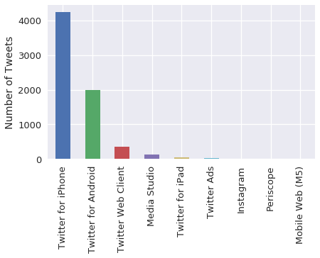

```python
trump['source'].value_counts().plot(kind="bar")
plt.ylabel("Number of Tweets")
```

## Question 4b

Is there a difference between his Tweet behavior across these devices? We will attempt to answer this question in our subsequent analysis.

First, we'll take a look at whether Trump's tweets from an Android come at different times than his tweets from an iPhone. Note that Twitter gives us his tweets in the [UTC timezone](https://www.wikiwand.com/en/List_of_UTC_time_offsets) (notice the `+0000` in the first few tweets)

```python
for t in trump_tweets[0:3]:
    print(t['created_at'])
```

```
Sun Feb 25 19:43:34 +0000 2018
Sun Feb 25 03:56:04 +0000 2018
Sun Feb 25 03:11:28 +0000 2018
```

We'll convert the tweet times to US Eastern Time, the timezone of New York and Washington D.C., since those are the places we would expect the most tweet activity from Trump.

```python
trump['est_time'] = (
    trump['time'].dt.tz_localize("UTC") # Set initial timezone to UTC
                 .dt.tz_convert("EST") # Convert to Eastern Time
)
trump.head()
```

| id | time | source | text | retweet_count | est_time |
| --- | --- | --- | --- | --- | --- |
| 690171032150237184 | 2016-01-21 13:56:11 | Twitter for Android | "@bigop1: @realDonaldTrump @SarahPalinUSA https://t.co/3kYQGqeVyD" | 1059 | 2016-01-21 08:56:11-05:00 |
| 690171403388104704 | 2016-01-21 13:57:39 | Twitter for Android | "@AmericanAsPie: @glennbeck @SarahPalinUSA Remember when Glenn gave out gifts to ILLEGAL ALIENS at crossing the border? Me too!" | 1339 | 2016-01-21 08:57:39-05:00 |
| 690173226341691392 | 2016-01-21 14:04:54 | Twitter for Android | So sad that @CNN and many others refused to show the massive crowd at the arena yesterday in Oklahoma. Dishonest reporting! | 2006 | 2016-01-21 09:04:54-05:00 |
| 690176882055114758 | 2016-01-21 14:19:26 | Twitter for Android | Sad sack @JebBush has just done another ad on me, with special interest money, saying I won't beat Hillary - I WILL. But he can't beat me. | 2266 | 2016-01-21 09:19:26-05:00 |
| 690180284189310976 | 2016-01-21 14:32:57 | Twitter for Android | Low energy candidate @JebBush has wasted $80 million on his failed presidential campaign. Millions spent on me. He should go home and relax! | 2886 | 2016-01-21 09:32:57-05:00 |

**What you need to do:**

Add a column called `hour` to the `trump` table which contains the hour of the day as floating point number computed by:

$$ \text{hour} + \frac{\text{minute}}{60} + \frac{\text{second}}{60^2} $$

```python
splice_time = [re.findall('(\d+)-(\d+)-(\d+) (\d+):(\d+):(\d+)', str(line)) for line in trump['est_time']]
hour = [(float(line[0][3]) + (float(line[0][4])/60) + (float(line[0][5])/(60**2))) for line in splice_time]

trump['hour'] = hour

# make a bar plot here
# YOUR CODE HERE
#raise NotImplementedError()
```

```python
assert np.isclose(trump.loc[690171032150237184]['hour'], 8.93639)
```

## Question 4c

Use this data along with the seaborn `distplot` function to examine the distribution over hours of the day in `easter time` that trump tweets on each device for the 2 most commonly used devices. Your plot should look similar to the following.

[figure not shown]

```
Text(0,0.5,'fraction')
```

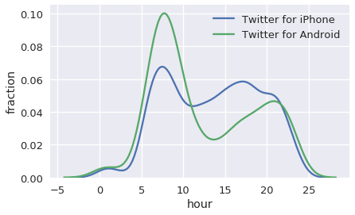

```python
### make your plot here
# YOUR CODE HERE
plt_vals = trump[['hour', 'source']].set_index('source').loc[['Twitter for iPhone', 'Twitter for Android']]#.loc[(trump['source'] == ('Twitter for iPhone' or 'Twitter for Android'))]
#df.loc[df.index < '2013-10-16 08:00:00']
#x = plt_vals.groupby(['source','hour']).count()
iPhone = plt_vals.loc[plt_vals.index == 'Twitter for iPhone']
android = plt_vals.loc[plt_vals.index == 'Twitter for Android']
#x
sns.distplot(iPhone['hour'], hist = False, label = 'Twitter for iPhone')#(trump['hour'])
sns.distplot(android['hour'], hist = False, label = 'Twitter for Android')
plt.ylabel('fraction')
#x
#sns.distplot(plt_vals['hour'])
#raise NotImplementedError()
```

## Question 4d

Are there any striking differences between these curves. If someone told you that Trump tends to tweet early in the morning and then later in the evening, which device might you conclude is most likely his?

## Question 5

Let's now look at which device he has used over the entire time period of this dataset.

To examine the distribution of dates we will convert the date to a fractional year that can be plotted as a distribution.

(Code borrowed from https://stackoverflow.com/questions/6451655/python-how-to-convert-datetime-dates-to-decimal-years)

```python
import datetime
def year_fraction(date):
    start = datetime.date(date.year, 1, 1).toordinal()
    year_length = datetime.date(date.year+1, 1, 1).toordinal() - start
    return date.year + float(date.toordinal() - start) / year_length


trump['year'] = trump['time'].apply(year_fraction)
```

### Question 5a

Use the `sns.distplot` to overlay the distributions of the 2 most frequently used web technologies over the years. Your final plot should look like:

[figure not shown]

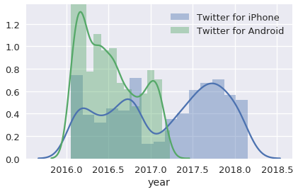

```python
# YOUR CODE HERE
trump_yr = trump[['source', 'year']].set_index('source')
#iPhone = plt_vals.loc[plt_vals.index == 'Twitter for iPhone']
iphone_yr = trump_yr.loc[trump_yr.index == 'Twitter for iPhone']
android_yr = trump_yr.loc[trump_yr.index == 'Twitter for Android']
sns.distplot(iphone_yr['year'], label = 'Twitter for iPhone')
sns.distplot(android_yr['year'], label = 'Twitter for Android')
plt.legend()
#raise NotImplementedError()
```

### Question 5b

According to the plot, Trump's tweets come from many different sources. It turns out that many of his tweets were not from Trump himself but from his staff. [Take a look at this Verge article.](https://www.theverge.com/2017/3/29/15103504/donald-trump-iphone-using-switched-android)

Does the data support the information in the article? What else do you find out about changes in Trump's tweets sources from the plot?

The data supports this article because Trump stopped Android texts and switched to iPhone. There isn't enough data to support that his staff sent out tweets because when the Android tweets decreased, the iPhone ones increased significantly.

## Question 6: Sentiment Analysis

It turns out that we can use the words in Trump's tweets to calculate a measure of the sentiment of the tweet. For example, the sentence "I love America!" has positive sentiment, whereas the sentence "I hate taxes!" has a negative sentiment. In addition, some words have stronger positive / negative sentiment than others: "I love America." is more positive than "I like America."

We will use the [VADER (Valence Aware Dictionary and sEntiment Reasoner)](https://github.com/cjhutto/vaderSentiment) lexicon to analyze the sentiment of Trump's tweets. VADER is a lexicon and rule-based sentiment analysis tool that is specifically attuned to sentiments expressed in social media which is great for our usage.

The VADER lexicon gives the sentiment of individual words. Run the following cell to show the first few rows of the lexicon:

```python
print(''.join(open("vader_lexicon.txt").readlines()[:10]))
```

```
$:	-1.5	0.80623	[-1, -1, -1, -1, -3, -1, -3, -1, -2, -1]
%)	-0.4	1.0198	[-1, 0, -1, 0, 0, -2, -1, 2, -1, 0]
%-)	-1.5	1.43178	[-2, 0, -2, -2, -1, 2, -2, -3, -2, -3]
&-:	-0.4	1.42829	[-3, -1, 0, 0, -1, -1, -1, 2, -1, 2]
&:	-0.7	0.64031	[0, -1, -1, -1, 1, -1, -1, -1, -1, -1]
( '}{' )	1.6	0.66332	[1, 2, 2, 1, 1, 2, 2, 1, 3, 1]
(%	-0.9	0.9434	[0, 0, 1, -1, -1, -1, -2, -2, -1, -2]
('-:	2.2	1.16619	[4, 1, 4, 3, 1, 2, 3, 1, 2, 1]
(':	2.3	0.9	[1, 3, 3, 2, 2, 4, 2, 3, 1, 2]
((-:	2.1	0.53852	[2, 2, 2, 1, 2, 3, 2, 2, 3, 2]
```

## Question 6a

As you can see, the lexicon contains emojis too! The first column of the lexicon is the *token*, or the word itself. The second column is the *polarity* of the word, or how positive / negative it is.

(How did they decide the polarities of these words? What are the other two columns in the lexicon? See the link above.)

Read in the lexicon into a DataFrame called `sent`. The index of the DF should be the tokens in the lexicon. `sent` should have one column: `polarity`: The polarity of each token.

```python
with open('vader_lexicon.txt') as f:
    log = f.readlines()

line = log[0]
line
x = [line.split('\t') for line in log]
sent = pd.DataFrame(x).rename(columns={0: 'tokens', 1: 'polarity'}).set_index('tokens')[['polarity']]
sent['polarity'] = pd.to_numeric(sent['polarity'])
# YOUR CODE HERE
#raise NotImplementedError()
```

```python
assert isinstance(sent, pd.DataFrame)
assert sent.shape == (7517, 1)
assert list(sent.index[5000:5005]) == ['paranoids', 'pardon', 'pardoned', 'pardoning', 'pardons']
assert np.allclose(sent['polarity'].head(), [-1.5, -0.4, -1.5, -0.4, -0.7])
```

## Question 6b

Now, let's use this lexicon to calculate the overall sentiment for each of Trump's tweets. Here's the basic idea:

1. For each tweet, find the sentiment of each word.
2. Calculate the sentiment of each tweet by taking the sum of the sentiments of its words.

First, let's lowercase the text in the tweets since the lexicon is also lowercase. Set the `text` column of the `trump` DF to be the lowercased text of each tweet.

```python
# YOUR CODE HERE
trump['text'] = [text.lower() for text in trump['text']]
#raise NotImplementedError()
```

```python
assert trump['text'].loc[884740553040175104] == 'working hard to get the olympics for the united states (l.a.). stay tuned!'
```

## Question 6c

Now, let's get rid of punctuation since it'll cause us to fail to match words. Create a new column called `no_punc` in the `trump` DF to be the lowercased text of each tweet with all punctuation replaced by a single space. We consider punctuation characters to be any character that isn't a Unicode word character or a whitespace character. You may want to consult the Python documentation on regexes for this problem.

(Why don't we simply remove punctuation instead of replacing with a space? See if you can figure this out by looking at the tweet data.)

```python
# Save your regex in punct_re
punct_re = r'[^(\s\w)]'
trump['no_punc'] = trump['text'].str.replace(punct_re, ' ') #[re.sub('\s', punct_re, punc) for punc in trump['text']]
# YOUR CODE HERE
#raise NotImplementedError()
```

```python
assert isinstance(punct_re, str)
assert re.search(punct_re, 'this') is None
assert re.search(punct_re, 'this is ok') is None
assert re.search(punct_re, 'this is\nok') is None
assert re.search(punct_re, 'this is not ok.') is not None
assert re.search(punct_re, 'this#is#ok') is not None
assert re.search(punct_re, 'this^is ok') is not None
assert trump['no_punc'].loc[800329364986626048] == 'i watched parts of  nbcsnl saturday night live last night  it is a totally one sided  biased show   nothing funny at all  equal time for us '
assert trump['no_punc'].loc[894620077634592769] == 'on  purpleheartday i thank all the brave men and women who have sacrificed in battle for this great nation   usa   https   t co qmfdlslp6p'
# If you fail these tests, you accidentally changed the text column
assert trump['text'].loc[884740553040175104] == 'working hard to get the olympics for the united states (l.a.). stay tuned!'
```

## Question 6d:

Now, let's convert the tweets into what's called a [*tidy format*](https://cran.r-project.org/web/packages/tidyr/vignettes/tidy-data.html) to make the sentiments easier to calculate. Use the `no_punc` column of `trump` to create a table called `tidy_format`. The index of the table should be the IDs of the tweets, repeated once for every word in the tweet. It has two columns:

1. `num`: The location of the word in the tweet. For example, if the tweet was "i love america", then the location of the word "i" is 0, "love" is 1, and "america" is 2.
2. `word`: The individual words of each tweet.

The first few rows of our `tidy_format` table look like:

|  | num | word |
| --- | --- | --- |
| 894661651760377856 | 0 | i |
| 894661651760377856 | 1 | think |
| 894661651760377856 | 2 | senator |
| 894661651760377856 | 3 | blumenthal |
| 894661651760377856 | 4 | should |

**Note that you'll get different results depending on when you pulled in the tweets.** However, you can double check that your tweet with ID `894661651760377856` has the same rows as ours. Our tests don't check whether your table looks exactly like ours.

This will require some rather advanced Pandas hacking, but our solution uses a chain of 5 methods on the `trump` DF.

- **Hint 1:** Try looking at the `expand` argument to pandas' `str.split`.
- **Hint 2:** Try looking at the `stack()` method.

```python
#tidy_format =
x = trump['no_punc']
x
remove_space = x.str.replace('\s+', ' ')#[punc.split('\s*', expand=True) for punc in x]
remove_space
no_space = pd.DataFrame(remove_space.str.split(expand=True).stack())
no_space.reset_index(inplace=True)
tidy_format = no_space.set_index('id').rename(columns={'level_1': 'num', 0: 'word'})
#no_space.groupby('id')
#tidy_format
# YOUR CODE HERE
#raise NotImplementedError()
```

```python
assert tidy_format.loc[894661651760377856].shape == (27, 2)
assert ' '.join(list(tidy_format.loc[894661651760377856]['word'])) == 'i think senator blumenthal should take a nice long vacation in vietnam where he lied about his service so he can at least say he was there'
```

## Question 6e:

Now that we have this table in the tidy format, it becomes much easier to find the sentiment of each tweet: we can join the table with the lexicon table.

Add a `polarity` column to the `trump` table. The `polarity` column should contain the sum of the sentiment polarity of each word in the text of the tweet.

**Hint** you will need to merge the `tidy_format` and `sent` tables and group the final answer.

```python
#x = tidy_format.groupby('word').count()
#sent ... tokens
# sent.index_name = 'tokens'
# sent.rename_axis('tokens')
#sent['token'] = sent.index
#sent = sent[['token', 'polarity']].set_index('')
polarity_sum = (
    tidy_format
        #.groupby('word').count()
        .merge(sent,
            how = "inner",
            left_on = "word", right_index = True)
        .groupby('id').sum()
        #.rename(columns = {'polarity': 'polarity_sum'})
)
#polarity_sum.rename(columns = {'polarity': 'polarity_sum'})
# p_sum = (
#     polarity_sum
#          .merge(trump,
#                how = "inner",
#                left_index = True, right_index = True)
# )
trump['polarity'] = polarity_sum[['polarity']]
trump = trump.fillna(value=0)
#x.loc[744701872456536064, 'polarity']
#trump.loc[744701872456536064, 'polarity']
#polarity_sum = polarity_sum.groupby('id').sum()
#polarity_sum

#trump --> no_punc
trump
# YOUR CODE HERE
#raise NotImplementedError()
#tidy_format.join(sent).groupby('polarity').count()
```

| id | time | source | text | retweet_count | est_time | hour | year | no_punc | polarity |
| --- | --- | --- | --- | --- | --- | --- | --- | --- | --- |
| 690171032150237184 | 2016-01-21 13:56:11 | Twitter for Android | "@bigop1: @realdonaldtrump @sarahpalinusa https://t.co/3kyqgqevyd" | 1059 | 2016-01-21 08:56:11-05:00 | 8.936389 | 2016.054645 | bigop1 realdonaldtrump sarahpalinusa https t co 3kyqgqevyd | 0.0 |
| 690171403388104704 | 2016-01-21 13:57:39 | Twitter for Android | "@americanaspie: @glennbeck @sarahpalinusa remember when glenn gave out gifts to illegal aliens at crossing the border? me too!" | 1339 | 2016-01-21 08:57:39-05:00 | 8.960833 | 2016.054645 | americanaspie glennbeck sarahpalinusa remember when glenn gave out gifts to illegal aliens at crossing the border me too | -2.6 |
| 690173226341691392 | 2016-01-21 14:04:54 | Twitter for Android | so sad that @cnn and many others refused to show the massive crowd at the arena yesterday in oklahoma. dishonest reporting! | 2006 | 2016-01-21 09:04:54-05:00 | 9.081667 | 2016.054645 | so sad that cnn and many others refused to show the massive crowd at the arena yesterday in oklahoma dishonest reporting | -6.0 |
| 690176882055114758 | 2016-01-21 14:19:26 | Twitter for Android | sad sack @jebbush has just done another ad on me, with special interest money, saying i won't beat hillary - i will. but he can't beat me. | 2266 | 2016-01-21 09:19:26-05:00 | 9.323889 | 2016.054645 | sad sack jebbush has just done another ad on me with special interest money saying i won t beat hillary i will but he can t beat me | 4.3 |
| 690180284189310976 | 2016-01-21 14:32:57 | Twitter for Android | low energy candidate @jebbush has wasted $80 million on his failed presidential campaign. millions spent on me. he should go home and relax! | 2886 | 2016-01-21 09:32:57-05:00 | 9.549167 | 2016.054645 | low energy candidate jebbush has wasted 80 million on his failed presidential campaign millions spent on me he should go home and relax | -2.6 |
| 690271688127213568 | 2016-01-21 20:36:09 | Twitter for iPhone | new day on cnn treats me very badly. @alisyncamerota is a disaster. not going to watch anymore. | 1429 | 2016-01-21 15:36:09-05:00 | 15.602500 | 2016.054645 | new day on cnn treats me very badly alisyncamerota is a disaster not going to watch anymore | -5.2 |
| 690272687168458754 | 2016-01-21 20:40:07 | Twitter for Android | happy birthday to my friend, the great @jacknicklaus - a totally special guy! | 1053 | 2016-01-21 15:40:07-05:00 | 15.668611 | 2016.054645 | happy birthday to my friend the great jacknicklaus a totally special guy | 9.7 |
| 690313350278819840 | 2016-01-21 23:21:42 | Twitter for iPhone | thank you, iowa! #trump2016 https://t.co/ryhehetlqn | 2329 | 2016-01-21 18:21:42-05:00 | 18.361667 | 2016.054645 | thank you iowa trump2016 https t co ryhehetlqn | 1.5 |
| 690315202261155840 | 2016-01-21 23:29:04 | Twitter for iPhone | thank you! #trump2016 https://t.co/pcdmyio1zt | 1463 | 2016-01-21 18:29:04-05:00 | 18.484444 | 2016.054645 | thank you trump2016 https t co pcdmyio1zt | 1.5 |
| 690315366564626433 | 2016-01-21 23:29:43 | Twitter for iPhone | thank you, new hampshire!\n#trump2016 https://t.co/tg9ozkly4l | 1761 | 2016-01-21 18:29:43-05:00 | 18.495278 | 2016.054645 | thank you new hampshire \n trump2016 https t co tg9ozkly4l | 1.5 |
| 690315667636023296 | 2016-01-21 23:30:55 | Twitter for iPhone | #trump2016 #makeamericagreatagain https://t.co/vfuwgigjn4 | 2217 | 2016-01-21 18:30:55-05:00 | 18.515278 | 2016.054645 | trump2016 makeamericagreatagain https t co vfuwgigjn4 | 0.0 |
| 690336644281581568 | 2016-01-22 00:54:16 | Twitter for iPhone | why does @greta have a fired bushy like dummy, john sununu on- spewing false info? i will beat hillary by a lot, she wants no part of trump. | 1576 | 2016-01-21 19:54:16-05:00 | 19.904444 | 2016.057377 | why does greta have a fired bushy like dummy john sununu on spewing false info i will beat hillary by a lot she wants no part of trump | -2.3 |
| 690337376061788161 | 2016-01-22 00:57:10 | Twitter for iPhone | thank you, iowa! #fitn #iacaucus\n#makeamericagreatagain #trump2016 https://t.co/wvjldvtsag | 2422 | 2016-01-21 19:57:10-05:00 | 19.952778 | 2016.057377 | thank you iowa fitn iacaucus\n makeamericagreatagain trump2016 https t co wvjldvtsag | 1.5 |
| 690382564494839809 | 2016-01-22 03:56:44 | Twitter for iPhone | national review is a failing publication that has lost it's way. it's circulation is way down w its influence being at an all time low. sad! | 2187 | 2016-01-21 22:56:44-05:00 | 22.945556 | 2016.057377 | national review is a failing publication that has lost it s way it s circulation is way down w its influence being at an all time low sad | -6.8 |
| 690382619213742082 | 2016-01-22 03:56:57 | Twitter for iPhone | very few people read the national review because it only knows how to criticize, but not how to lead. | 1817 | 2016-01-21 22:56:57-05:00 | 22.949167 | 2016.057377 | very few people read the national review because it only knows how to criticize but not how to lead | -1.6 |
| 690382722162913280 | 2016-01-22 03:57:22 | Twitter for iPhone | the late, great, william f. buckley would be ashamed of what had happened to his prize, the dying national review! | 2236 | 2016-01-21 22:57:22-05:00 | 22.956111 | 2016.057377 | the late great william f buckley would be ashamed of what had happened to his prize the dying national review | 3.3 |
| 690404308010057728 | 2016-01-22 05:23:08 | Twitter for iPhone | rt @williebosshog: make america great again! #trump2016 https://t.co/1h5j4dzdgy | 9144 | 2016-01-22 00:23:08-05:00 | 0.385556 | 2016.057377 | rt williebosshog make america great again trump2016 https t co 1h5j4dzdgy | 3.1 |
| 690528062190944256 | 2016-01-22 13:34:54 | Twitter for Android | ted cruz complains about my views on eminent domain, but without it we wouldn't have roads, highways, airports, schools or even pipelines. | 1595 | 2016-01-22 08:34:54-05:00 | 8.581667 | 2016.057377 | ted cruz complains about my views on eminent domain but without it we wouldn t have roads highways airports schools or even pipelines | -1.6 |
| 690528407117889538 | 2016-01-22 13:36:16 | Twitter for Android | "@realollietaylor: isn't it time we had a president? let goofy glen keep canada cruz who can't win. the american people have trump!" | 909 | 2016-01-22 08:36:16-05:00 | 8.604444 | 2016.057377 | realollietaylor isn t it time we had a president let goofy glen keep canada cruz who can t win the american people have trump | 2.8 |
| 690528526181601281 | 2016-01-22 13:36:44 | Twitter for Android | "@borntobegop: @realdonaldtrump no sleep for the #trumptrain!" | 676 | 2016-01-22 08:36:44-05:00 | 8.612222 | 2016.057377 | borntobegop realdonaldtrump no sleep for the trumptrain | -1.2 |
| 690529122326413314 | 2016-01-22 13:39:06 | Twitter for Android | "@neilturner_: @realdonaldtrump https://t.co/uvn95nb6m0 with your help we can #makeamericagreatagain! #votetrump" | 773 | 2016-01-22 08:39:06-05:00 | 8.651667 | 2016.057377 | neilturner_ realdonaldtrump https t co uvn95nb6m0 with your help we can makeamericagreatagain votetrump | 1.7 |
| 690529690205818880 | 2016-01-22 13:41:22 | Twitter for Android | #tedcruz eligibility to be president not settled law, says cruz' constitutional law professor, #laurencetribe https://t.co/gwkojsbinz" | 753 | 2016-01-22 08:41:22-05:00 | 8.689444 | 2016.057377 | tedcruz eligibility to be president not settled law says cruz constitutional law professor laurencetribe https t co gwkojsbinz | 0.0 |
| 690530164711624705 | 2016-01-22 13:43:15 | Twitter for Android | "@trublumajority: #laurencetribe calls cruz "constitutional hypocrite" on @wbur https://t.co/qrfintcjlx @pbsgwen @charlierose @jaketapper | 637 | 2016-01-22 08:43:15-05:00 | 8.720833 | 2016.057377 | trublumajority laurencetribe calls cruz constitutional hypocrite on wbur https t co qrfintcjlx pbsgwen charlierose jaketapper | 0.0 |
| 690532959363866625 | 2016-01-22 13:54:21 | Twitter for Android | highly respected constitutional law professor mary brigid mcmanamon has just stated, "ted cruz is not eligible to be president." big problem | 1937 | 2016-01-22 08:54:21-05:00 | 8.905833 | 2016.057377 | highly respected constitutional law professor mary brigid mcmanamon has just stated ted cruz is not eligible to be president big problem | 0.4 |
| 690534215478173697 | 2016-01-22 13:59:21 | Twitter for Android | "@d: #marybrigidmcmanamon, washington post: constitutionally speaking, #cruz simply isn’t eligible to be president https://t.co/dbttgsc1il" | 875 | 2016-01-22 08:59:21-05:00 | 8.989167 | 2016.057377 | d marybrigidmcmanamon washington post constitutionally speaking cruz simply isn t eligible to be president https t co dbttgsc1il | 0.0 |
| 690534576066719744 | 2016-01-22 14:00:47 | Twitter for Android | "@cyberciety: #marybrigidmcmanamon clarified how #commonlaw is used to interpret meaning of #naturalborn #tedcruz https://t.co/5y6szrtdgr" | 799 | 2016-01-22 09:00:47-05:00 | 9.013056 | 2016.057377 | cyberciety marybrigidmcmanamon clarified how commonlaw is used to interpret meaning of naturalborn tedcruz https t co 5y6szrtdgr | 0.0 |
| 690537121916923904 | 2016-01-22 14:10:54 | Twitter for Android | "@miaminewtimes: poll: trump has more support in florida than rubio and bush combined. https://t.co/uvh2bkqrhf https://t.co/2tviaa2afr" | 1738 | 2016-01-22 09:10:54-05:00 | 9.181667 | 2016.057377 | miaminewtimes poll trump has more support in florida than rubio and bush combined https t co uvh2bkqrhf https t co 2tviaa2afr | 1.7 |
| 690540484154896384 | 2016-01-22 14:24:15 | Twitter for Android | the failing @nro national review magazine has just been informed by the republican national committee that they cannot participate in debate | 2116 | 2016-01-22 09:24:15-05:00 | 9.404167 | 2016.057377 | the failing nro national review magazine has just been informed by the republican national committee that they cannot participate in debate | -2.3 |
| 690560125916975104 | 2016-01-22 15:42:18 | Twitter for Android | after spending $89 million, @jebbush is at the bottom of the barrel in polls. he is ashamed to use the name "bush" in ads. low energy guy! | 1661 | 2016-01-22 10:42:18-05:00 | 10.705000 | 2016.057377 | after spending 89 million jebbush is at the bottom of the barrel in polls he is ashamed to use the name bush in ads low energy guy | -2.1 |
| 690560942430523392 | 2016-01-22 15:45:33 | Twitter for Android | "@lisa_milicaj: truth be told, i never heard of the national review until they "tried" to declare war on you. no worries, you got my vote!" | 1110 | 2016-01-22 10:45:33-05:00 | 10.759167 | 2016.057377 | lisa_milicaj truth be told i never heard of the national review until they tried to declare war on you no worries you got my vote | -4.6 |
| ... | ... | ... | ... | ... | ... | ... | ... | ... | ... |
| 966681883206668289 | 2018-02-22 14:31:35 | Twitter for iPhone | what many people don’t understand, or don’t want to understand, is that wayne, chris and the folks who work so hard at the @nra are great people and great american patriots. they love our country and … | 22502 | 2018-02-22 09:31:35-05:00 | 9.526389 | 2018.142466 | what many people don t understand or don t want to understand is that wayne chris and the folks who work so hard at the nra are great people and great american patriots they love our country and will … | 12.4 |
| 966687491616059392 | 2018-02-22 14:53:52 | Twitter for iPhone | will be meeting with lawmakers today at 11:30 a.m. to discuss school safety. next week it will be with our nation’s governors. it’s been many years of all talk, no action. we’ll get it done! | 19697 | 2018-02-22 09:53:52-05:00 | 9.897778 | 2018.142466 | will be meeting with lawmakers today at 11 30 a m to discuss school safety next week it will be with our nation s governors it s been many years of all talk no action we ll get it done | 0.6 |
| 966711641378381826 | 2018-02-22 16:29:50 | Media Studio | on behalf of an entire nation, congratulations to the u.s. women's hockey team on winning the gold! #goteamusa #olympics https://t.co/3cuzwlvgua | 18194 | 2018-02-22 11:29:50-05:00 | 11.497222 | 2018.142466 | on behalf of an entire nation congratulations to the u s women s hockey team on winning the gold goteamusa olympics https t co 3cuzwlvgua | 5.3 |
| 966766375292358659 | 2018-02-22 20:07:20 | Twitter for iPhone | today, it was my great honor to host a school safety roundtable at the @whitehouse with state and local leaders, law enforcement officers, and education officials.\n\nthere is nothing more important t… | 18474 | 2018-02-22 15:07:20-05:00 | 15.122222 | 2018.142466 | today it was my great honor to host a school safety roundtable at the whitehouse with state and local leaders law enforcement officers and education officials \n\nthere is nothing more important than … | 9.8 |
| 966846679784837120 | 2018-02-23 01:26:26 | Twitter for iPhone | “school shooting survivor says he quit @cnn town hall after refusing scripted question.” @tuckercarlson. just like so much of cnn, fake news. that’s why their ratings are so bad! msnbc may be worse. | 31773 | 2018-02-22 20:26:26-05:00 | 20.440556 | 2018.145205 | school shooting survivor says he quit cnn town hall after refusing scripted question tuckercarlson just like so much of cnn fake news that s why their ratings are so bad msnbc may be worse | -5.4 |
| 966998215592677376 | 2018-02-23 11:28:35 | Twitter for iPhone | ms-13 gang members are being removed by our great ice and border patrol agents by the thousands, but these killers come back in from el salvador, and through mexico, like water. el salvador just takes… | 28003 | 2018-02-23 06:28:35-05:00 | 6.476389 | 2018.145205 | ms 13 gang members are being removed by our great ice and border patrol agents by the thousands but these killers come back in from el salvador and through mexico like water el salvador just takes our… | 1.3 |
| 967021512455802881 | 2018-02-23 13:01:09 | Twitter for iPhone | cpac today! | 7726 | 2018-02-23 08:01:09-05:00 | 8.019167 | 2018.145205 | cpac today | 0.0 |
| 967023015035797504 | 2018-02-23 13:07:07 | Twitter for iPhone | my daughter, ivanka, just arrived in south korea. we cannot have a better, or smarter, person representing our country. | 14316 | 2018-02-23 08:07:07-05:00 | 8.118611 | 2018.145205 | my daughter ivanka just arrived in south korea we cannot have a better or smarter person representing our country | 3.9 |
| 967023714268319744 | 2018-02-23 13:09:54 | Twitter for iPhone | for those of you who are still interested, the democrats have totally forgotten about daca. not a lot of interest on this subject from them! | 24477 | 2018-02-23 08:09:54-05:00 | 8.165000 | 2018.145205 | for those of you who are still interested the democrats have totally forgotten about daca not a lot of interest on this subject from them | 2.8 |
| 967083281974951939 | 2018-02-23 17:06:36 | Twitter for iPhone | after years of rebuilding other nations, we are finally rebuilding our nation - and we are restoring our confidence and our pride! #cpac2018 https://t.co/rd9otu8iex | 15643 | 2018-02-23 12:06:36-05:00 | 12.110000 | 2018.145205 | after years of rebuilding other nations we are finally rebuilding our nation and we are restoring our confidence and our pride cpac2018 https t co rd9otu8iex | 4.9 |
| 967083810981597185 | 2018-02-23 17:08:42 | Twitter for iPhone | we salute our great american flag, we put our hands on our hearts for the pledge of allegiance, and we all proudly stand for the national anthem. #cpac2018 https://t.co/qgkw2xgjp0 | 16420 | 2018-02-23 12:08:42-05:00 | 12.145000 | 2018.145205 | we salute our great american flag we put our hands on our hearts for the pledge of allegiance and we all proudly stand for the national anthem cpac2018 https t co qgkw2xgjp0 | 5.7 |
| 967084806726127616 | 2018-02-23 17:12:40 | Twitter for iPhone | our nation’s motto is in god we trust. this week, our nation lost an incredible leader who devoted his life to helping us understand what those words really mean. we will never forget the historic cro… | 20279 | 2018-02-23 12:12:40-05:00 | 12.211111 | 2018.145205 | our nation s motto is in god we trust this week our nation lost an incredible leader who devoted his life to helping us understand what those words really mean we will never forget the historic crowds… | 7.0 |
| 967146956094083073 | 2018-02-23 21:19:37 | Twitter for iPhone | today, @flotus melania and i were honored to welcome prime minister @turnbullmalcolm and mrs. turnbull of australia to the @whitehouse!\n\n🇺🇸🇦🇺press conference: https://t.co/rkokjgrsgu https://t.co/pk… | 8698 | 2018-02-23 16:19:37-05:00 | 16.326944 | 2018.145205 | today flotus melania and i were honored to welcome prime minister turnbullmalcolm and mrs turnbull of australia to the whitehouse \n\n press conference https t co rkokjgrsgu https t co pkjuw8x9jb | 4.8 |
| 967168890232082433 | 2018-02-23 22:46:47 | Twitter for iPhone | thank you to the great men and women of the united states @secretservice for a job well done! | 15275 | 2018-02-23 17:46:47-05:00 | 17.779722 | 2018.145205 | thank you to the great men and women of the united states secretservice for a job well done | 7.5 |
| 967388904952344577 | 2018-02-24 13:21:02 | Twitter for iPhone | so true wayne, and lowest black unemployment in history! https://t.co/gdxxjdzqum | 19952 | 2018-02-24 08:21:02-05:00 | 8.350556 | 2018.147945 | so true wayne and lowest black unemployment in history https t co gdxxjdzqum | -1.7 |
| 967389553362423808 | 2018-02-24 13:23:37 | Twitter for iPhone | rt @realdonaldtrump: i will be strongly pushing comprehensive background checks with an emphasis on mental health. raise age to 21 and end… | 36986 | 2018-02-24 08:23:37-05:00 | 8.393611 | 2018.147945 | rt realdonaldtrump i will be strongly pushing comprehensive background checks with an emphasis on mental health raise age to 21 and end | 2.1 |
| 967472757025001472 | 2018-02-24 18:54:14 | Twitter for iPhone | armed educators (and trusted people who work within a school) love our students and will protect them. very smart people. must be firearms adept &amp; have annual training. should get yearly bonus. sh… | 20152 | 2018-02-24 13:54:14-05:00 | 13.903889 | 2018.147945 | armed educators (and trusted people who work within a school) love our students and will protect them very smart people must be firearms adept amp have annual training should get yearly bonus shooting… | 11.1 |
| 967493467046899712 | 2018-02-24 20:16:32 | Twitter for iPhone | democrat judges have totally redrawn election lines in the great state of pennsylvania. @foxnews. this is very unfair to republicans and to our country as a whole. must be appealed to the united state… | 21915 | 2018-02-24 15:16:32-05:00 | 15.275556 | 2018.147945 | democrat judges have totally redrawn election lines in the great state of pennsylvania foxnews this is very unfair to republicans and to our country as a whole must be appealed to the united states su… | 5.4 |
| 967506350283599874 | 2018-02-24 21:07:43 | Twitter for iPhone | unemployment claims are at the lowest level since 1973. much of this has to do with the massive cutting of unnecessary and job killing regulations! | 15424 | 2018-02-24 16:07:43-05:00 | 16.128611 | 2018.147945 | unemployment claims are at the lowest level since 1973 much of this has to do with the massive cutting of unnecessary and job killing regulations | -7.4 |
| 967508938425069568 | 2018-02-24 21:18:01 | Twitter for iPhone | dems are no longer talking daca! “out of sight, out of mind,” they say. daca beneficiaries should not be happy. nancy pelosi truly doesn’t care about them. republicans stand ready to make a deal! | 21648 | 2018-02-24 16:18:01-05:00 | 16.300278 | 2018.147945 | dems are no longer talking daca out of sight out of mind they say daca beneficiaries should not be happy nancy pelosi truly doesn t care about them republicans stand ready to make a deal | 8.9 |
| 967526110249537542 | 2018-02-24 22:26:15 | Twitter for iPhone | big cpac straw poll results: 93% approve of the job president trump is doing (thank you!). 50% say president trump should tweet more or same (funny!). 79% say republicans in congress should do a bette… | 24439 | 2018-02-24 17:26:15-05:00 | 17.437500 | 2018.147945 | big cpac straw poll results 93 approve of the job president trump is doing (thank you ) 50 say president trump should tweet more or same (funny ) 79 say republicans in congress should do a better job … | 1.9 |
| 967538684789739520 | 2018-02-24 23:16:13 | Twitter for iPhone | the democrat memo response on government surveillance abuses is a total political and legal bust. just confirms all of the terrible things that were done. so illegal! | 20118 | 2018-02-24 18:16:13-05:00 | 18.270278 | 2018.147945 | the democrat memo response on government surveillance abuses is a total political and legal bust just confirms all of the terrible things that were done so illegal | -6.8 |
| 967539664692350977 | 2018-02-24 23:20:06 | Twitter for iPhone | dem memo: fbi did not disclose who the clients were - the clinton campaign and the dnc. wow! | 20815 | 2018-02-24 18:20:06-05:00 | 18.335000 | 2018.147945 | dem memo fbi did not disclose who the clients were the clinton campaign and the dnc wow | 2.8 |
| 967545724362739712 | 2018-02-24 23:44:11 | Twitter for iPhone | “russians had no compromising information on donald trump” @foxnews of course not, because there is none, and never was. this whole witch hunt is an illegal disgrace...and obama did nothing about russ… | 18464 | 2018-02-24 18:44:11-05:00 | 18.736389 | 2018.147945 | russians had no compromising information on donald trump foxnews of course not because there is none and never was this whole witch hunt is an illegal disgrace and obama did nothing about russia | -7.5 |
| 967563946063523840 | 2018-02-25 00:56:35 | Twitter for iPhone | “congressman schiff omitted and distorted key facts” @foxnews so, what else is new. he is a total phony! | 18532 | 2018-02-24 19:56:35-05:00 | 19.943056 | 2018.150685 | congressman schiff omitted and distorted key facts foxnews so what else is new he is a total phony | -1.7 |
| 967564998238142471 | 2018-02-25 01:00:46 | Twitter for iPhone | i will be interviewed by @judgejeanine on @foxnews at 9:00 p.m. enjoy! | 8280 | 2018-02-24 20:00:46-05:00 | 20.012778 | 2018.150685 | i will be interviewed by judgejeanine on foxnews at 9 00 p m enjoy | 2.2 |
| 967597639293382657 | 2018-02-25 03:10:28 | Twitter for iPhone | rt @foxnews: president @realdonaldtrump on daca: "i'm the one that's pushing daca and the democrats are nowhere to be found." https://t.co/… | 12092 | 2018-02-24 22:10:28-05:00 | 22.174444 | 2018.150685 | rt foxnews president realdonaldtrump on daca i m the one that s pushing daca and the democrats are nowhere to be found https t co | 0.0 |
| 967597887545896961 | 2018-02-25 03:11:28 | Twitter for iPhone | rt @foxnews: president @realdonaldtrump on dem fisa memo: "a lot of bad things happened on the other side, not on this side, but the other… | 13201 | 2018-02-24 22:11:28-05:00 | 22.191111 | 2018.150685 | rt foxnews president realdonaldtrump on dem fisa memo a lot of bad things happened on the other side not on this side but the other | -2.5 |
| 967609114238050304 | 2018-02-25 03:56:04 | Twitter for iPhone | rt @vollrathtammie: @realdonaldtrump @foxnews https://t.co/seri7vyh5i | 6350 | 2018-02-24 22:56:04-05:00 | 22.934444 | 2018.150685 | rt vollrathtammie realdonaldtrump foxnews https t co seri7vyh5i | 0.0 |
| 967847560248426498 | 2018-02-25 19:43:34 | Twitter for iPhone | rt @whitehouse: merit-based immigration reform will benefit american workers and relieve the strain imposed by our current system on federa… | 11047 | 2018-02-25 14:43:34-05:00 | 14.726111 | 2018.150685 | rt whitehouse merit based immigration reform will benefit american workers and relieve the strain imposed by our current system on federa | 4.8 |

6794 rows × 9 columns

```python
assert np.allclose(trump.loc[744701872456536064, 'polarity'], 8.4)
assert np.allclose(trump.loc[745304731346702336, 'polarity'], 2.5)
assert np.allclose(trump.loc[744519497764184064, 'polarity'], 1.7)
assert np.allclose(trump.loc[894661651760377856, 'polarity'], 0.2)
assert np.allclose(trump.loc[894620077634592769, 'polarity'], 5.4)
# If you fail this test, you dropped tweets with 0 polarity
assert np.allclose(trump.loc[744355251365511169, 'polarity'], 0.0)
```

Now we have a measure of the sentiment of each of his tweets! Note that this calculation is rather basic; you can read over the VADER readme to understand a more robust sentiment analysis.

Now, run the cells below to see the most positive and most negative tweets from Trump in your dataset:

```python
print('Most negative tweets:')
for t in trump.sort_values('polarity').head()['text']:
    print('\n  ', t)
```

```
Most negative tweets:

   horrible and cowardly terrorist attack on innocent and defenseless worshipers in egypt. the world cannot tolerate terrorism, we must defeat them militarily and discredit the extremist ideology that forms the basis of their existence!

   democrat jon ossoff would be a disaster in congress. very weak on crime and illegal immigration, bad for jobs and wants higher taxes. say no

   "@fiiibuster: @jeffzeleny pathetic - you have no sufficient evidence that donald trump did not suffer from voter fraud, shame! bad reporter.

   nyc terrorist was happy as he asked to hang isis flag in his hospital room. he killed 8 people, badly injured 12. should get death penalty!

   yet another terrorist attack today in israel -- a father, shot at by a palestinian terrorist, was killed while:
https://t.co/cv1hzkvbit
```

```python
print('Most positive tweets:')
for t in trump.sort_values('polarity', ascending=False).head()['text']:
    print('\n  ', t)
```

```
Most positive tweets:

   thank you to linda bean of l.l.bean for your great support and courage. people will support you even more now. buy l.l.bean. @lbperfectmaine

   it was my great honor to celebrate the opening of two extraordinary museums-the mississippi state history museum &amp; the mississippi civil rights museum. we pay solemn tribute to our heroes of the past &amp; dedicate ourselves to building a future of freedom, equality, justice &amp; peace. http…

   rt @ivankatrump: 2016 has been one of the most eventful and exciting years of my life. i wish you peace, joy, love and laughter. happy new…

   today, it was my great honor to sign a new executive order to ensure veterans have the resources they need as they transition back to civilian life. we must ensure that our heroes are given the care and support they so richly deserve! https://t.co/0mdp9ddias https://t.co/lp2a8kcbap

   it was my great honor to welcome mayor’s from across america to the wh. my administration will always support local government - and listen to the leaders who know their communities best. together, we will usher in a bold new era of peace and prosperity! https://t.co/dmyectnk0a https://t.co/rsv7v…
```

## Question 6g

Plot the distribution of tweet sentiments broken down by whether the text of the tweet contains `nyt` or `fox`. Then in the box below comment on what we observe?

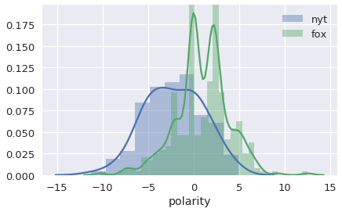

```python
# YOUR CODE HERE
t_nyt = trump[trump['no_punc'].str.contains('nyt')]['polarity']
t_fox = trump[trump['no_punc'].str.contains('fox')]['polarity']
t_nyt
sns.distplot(t_nyt, label = 'nyt')
sns.distplot(t_fox, label = 'fox')
plt.legend()

#x = trump[['no_punc']].str.contains('fox') #6794
#len(x)#trump[['no_punc']].head()
#raise NotImplementedError()
```

#### Comment on what you observe:

The polarity of Trump's tweets with the word 'fox' in them are higher which means they are more positive. There are peaks in the 'fox' tweets' polarity at 0 and 3. This means the tweets were typically neutral or slightly positive. However, the 'nyt' tweets overall had a lower polarity than the 'fox' tweets which means they are more negative. The majority of the 'nyt' tweets were between -7 and 1 polarity and there weren't any peals.

## Question 7: Engagement

## Question 7a

Which of Trump's tweets had the most retweets? Were there certain words that often led to more retweets?

We can find this out by using our `tidy_format` DataFrame. For each word in the `tidy_format` DF, find out the number of retweets that its tweet got. Filter out words that didn't appear in at least 25 tweets, find out the median number of retweets each word got, and save the top 20 most retweeted words into a DataFrame called `top_20`. Your `top_20` table should have this format:

| word | retweet_count |
| --- | --- |
| fake | 22963.0 |
| news | 20463.0 |
| ds100 | 20432.0 |
| great | 20159.0 |
| class | 20121.0 |

```python
t = (
    tidy_format
        .merge(trump,
            how = 'inner',
            left_index = True, right_index = True)
)


count = t[['word', 'retweet_count']].groupby('word').count()
at_least_25 = count[count['retweet_count'] >= 25]
t
final_table = (
    t
    .merge(at_least_25,
         how='inner',
         left_on='word', right_index=True)
)
final_table
f = final_table[['word','retweet_count_x']].groupby(['word']).sum()
real = f.merge(at_least_25,
           how='inner',
           left_index=True, right_index=True

)
real['average'] = real['retweet_count_x']/real['retweet_count']
real
#f
# #t
top_20 = real.sort_values('average', ascending=False).iloc[0:21]
top_20




# YOUR CODE HERE
#raise NotImplementedError()
```

| word | retweet_count_x | retweet_count | average |
| --- | --- | --- | --- |
| nfl | 777312 | 28 | 27761.142857 |
| flag | 688844 | 25 | 27553.760000 |
| billion | 728833 | 27 | 26993.814815 |
| anthem | 709433 | 27 | 26275.296296 |
| fbi | 2178773 | 85 | 25632.623529 |
| unemployment | 913062 | 36 | 25362.833333 |
| daca | 1320583 | 53 | 24916.660377 |
| emails | 815523 | 33 | 24712.818182 |
| collusion | 978449 | 40 | 24461.225000 |
| god | 1072131 | 44 | 24366.613636 |
| stated | 776425 | 32 | 24263.281250 |
| fake | 4916811 | 208 | 23638.514423 |
| friend | 603568 | 26 | 23214.153846 |
| russian | 965018 | 42 | 22976.619048 |
| happen | 756098 | 33 | 22912.060606 |
| russia | 2652661 | 116 | 22867.767241 |
| schumer | 661012 | 29 | 22793.517241 |
| perhaps | 628059 | 28 | 22430.678571 |
| comey | 775356 | 35 | 22153.028571 |
| iran | 818733 | 37 | 22127.918919 |
| including | 838440 | 38 | 22064.210526 |

```python
#### NOTE This Test is kind of iffy (very variable) - needs review before publishing

# Although it can't be guaranteed, it's very likely that the top 7 words will still be
# in the top 20 words in the next month.
assert 'daca'     in top_20.index
assert 'nfl'     in top_20.index
assert 'anthem' in top_20.index
assert 'fbi'    in top_20.index
assert 'russia'    in top_20.index
```

Here's a bar chart of your results:

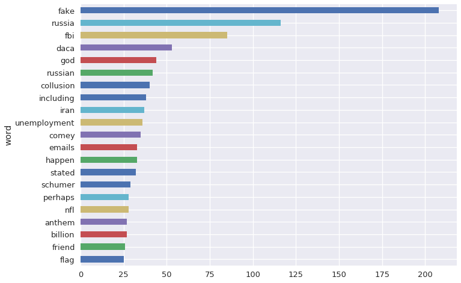

```python
top_20['retweet_count'].sort_values().plot.barh(figsize=(10, 8));
```

## Question 7b

The phrase "fake news" is apparently really popular! We can conclude that Trump's tweets containing "fake" and/or "news" result in the most retweets relative to words his other tweets. Or can we?

Consider each of the statements about possible confounding factors below. State whether each statement is true or false and explain. If the statement is true, state whether the confounding factor could have made "fake" and/or "news" higher on our list than they should be.

1. We didn't restrict our word list to nouns, so we have unhelpful words like "let" and "any" in our result.
2. We didn't remove hashtags in our text, so we have duplicate words (eg. #great and great).
3. We didn't account for the fact that Trump's follower count has increased over time.
1. True. This confounding factor could have made "fake" and/or "news" higher on the list because the list would remove words that are not nouns which could have more retweets than "fake" or "news."
2. False. We created a no_punc column in trump that contains any character that is not a Unicode character or whitespace character. This removes the hashtags in the text so there aren't duplicate words.
3. True. Trump's follower count is not a confounding factor, because it does not effect the words that Trump uses in his tweets. Thus, the increase in follwer count could not have made "fake" and/or "news" higher in our list than it should be.

## Question 8

Using the `trump` tweets construct an interesting plot describing a property of the data and discuss what you found below.

**Ideas:**

1. How has the sentiment changed with length of the tweets?
2. Does sentiment affect retweet count?
3. Are retweets more negative than regular tweets?
4. Are there any spikes in the number of retweets and do the correspond to world events?
5. *Bonus:* How many Russian twitter bots follow Trump?

You can look at other data sources and even tweets.

### Plot:

```
Text(0,0.5,'Average Polarity')
```

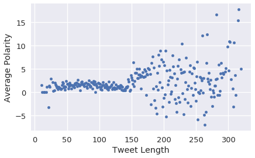

```python
# YOUR CODE HERE
trump['tweet_length'] = [len(sent) for sent in trump['no_punc']]

len_tweet = trump[['polarity', 'tweet_length']]
avg = len_tweet.groupby('tweet_length').mean()
avg['tweet_length']=avg.index
avg.plot(x='tweet_length', y='polarity', kind="scatter", use_index=True)
plt.xlabel('Tweet Length')
plt.ylabel('Average Polarity')
#raise NotImplementedError()
```

### Discussion:

# This graphs shows the average polarity with respect to tweet length. There is an overall positive correlation because as tweet length increases, the polarity tends to increase a tiny bit. From the tweet lengths of 0 to 150, the average polarity is slightly above 0, but after 150 tweets the average polarity tends to become more variable and scattered.

## Submission

Congrats, you just finished Project 1!